# Classification and Clustering of Low Birth Weight Mortality Using Global Health and Economic Data

ID: 24190901 - Name: Cedrus DANG

2025-05-20

# I. Introduction

The project aims to develop classifications and clustering models for public health research.

- Classification Goal: The models will classify the **Low Birth Weight** mortality levels of “High” and “Low” using the mean mortality rate. The models use the data set of causes of death and the data of GDP and Population from the World Bank. This cause of death was targeted due to its significant value in aid programs for children’s and mothers’ health and safety. For the single variable model, GDP per capita will be selected to build a fast classification.
- Clustering Goal: The models will Clustering the causes of death to groups with similar attributes and find the relationship between them to label their groups.

This analysis focuses on national-level data from multiple countries. Regional, sub-national data and dependent territories are excluded to ensure no unneeded outliers.

Decision Tree and Naive Bayesian modelling techniques will be compared to determine the most effective approach for classification and clustering to identify the best-performing models.

Several methods were used to assess and enhance the classification models’ performance. They are 10-fold cross-validation, Recursive Feature Elimination (RFE), confusion matrix, F1 score, and ROC-AUC metric.

Additional method not mentioned in the lectures is Recursive Feature Elimination (RFE).

RFE was applied to Decision Tree and Naive Bayes classification models in several papers (Painuli et al., 2023) (Mladenova et al., 2024). In those papers, the technique did improve the performance of the models. Additionally, the decision tree model showed better performance than the naive Bayes model due to high-dimensional data, which is similar to the findings in this paper, both in data and results.

# II. Data preparation

## 1. Death Causes Data

```r
library(knitr)
library(kableExtra)
death_causes <- read.csv("Countries and death causes.csv")
#Structure of the data
Structure <- capture.output(str(death_causes))
kable(as.data.frame(Structure), format = "html") %>% scroll_box(height = "490px")
```

| Structure |
| --- |
| ‘data.frame’: 6840 obs. of 31 variables: |
| $ Entity : chr “Afghanistan” “Afghanistan” “Afghanistan” “Afghanistan” … |
| $ Code : chr “AFG” “AFG” “AFG” “AFG” … |
| $ Year : int 1990 1991 1992 1993 1994 1995 1996 1997 1998 1999 … |
| $ Outdoor.air.pollution : int 3169 3222 3395 3623 3788 3869 3943 4024 4040 4042 … |
| $ High.systolic.blood.pressure : int 25633 25872 26309 26961 27658 28090 28587 29021 29349 29712 … |
| $ Diet.high.in.sodium : int 1045 1055 1075 1103 1134 1154 1178 1202 1222 1242 … |
| $ Diet.low.in.whole.grains : int 7077 7149 7297 7499 7698 7807 7943 8075 8173 8265 … |
| $ Alochol.use : int 356 364 376 389 399 406 413 420 425 426 … |
| $ Diet.low.in.fruits : int 3185 3248 3351 3480 3610 3703 3819 3938 4038 4127 … |
| $ Unsafe.water.source : int 3702 4309 5356 7152 7192 8378 8487 9348 9788 9931 … |
| $ Secondhand.smoke : int 4794 4921 5279 5734 6050 6167 6298 6425 6402 6323 … |
| $ Low.birth.weight : int 16135 17924 21200 23795 24866 25534 25997 26246 25805 25080 … |
| $ Child.wasting : int 19546 20334 22895 27002 29205 30943 31628 32736 32760 32271 … |
| $ Unsafe.sex : int 351 361 378 395 410 422 435 448 458 469 … |
| $ Diet.low.in.nuts.and.seeds : int 2319 2449 2603 2771 2932 3049 3173 3298 3401 3482 … |
| $ Household.air.pollution.from.solid.fuels: int 34372 35392 38065 41154 43153 44024 45005 46017 46055 45681 … |
| $ Diet.low.in.Vegetables : int 3679 3732 3827 3951 4075 4153 4247 4339 4409 4473 … |
| $ Low.physical.activity : int 2637 2652 2688 2744 2805 2839 2878 2914 2944 2976 … |
| $ Smoking : int 5174 5247 5363 5522 5689 5801 5934 6066 6178 6288 … |
| $ High.fasting.plasma.glucose : int 11449 11811 12265 12821 13400 13871 14413 14970 15502 16058 … |
| $ Air.pollution : int 37231 38315 41172 44488 46634 47566 48617 49703 49746 49349 … |
| $ High.body.mass.index : int 9518 9489 9528 9611 9675 9608 9503 9286 9024 8857 … |
| $ Unsafe.sanitation : int 2798 3254 4042 5392 5418 6313 6393 7038 7366 7468 … |
| $ No.access.to.handwashing.facility : int 4825 5127 5889 7007 7421 7896 8098 8507 8560 8424 … |
| $ Drug.use : int 174 188 211 232 247 260 274 287 295 302 … |
| $ Low.bone.mineral.density : int 389 389 393 411 413 417 423 425 429 428 … |
| $ Vitamin.A.deficiency : int 2016 2056 2100 2316 2665 3070 3214 3228 3413 3662 … |
| $ Child.stunting : int 7686 7886 8568 9875 11031 11973 12426 12805 13011 13052 … |
| $ Discontinued.breastfeeding : int 107 121 150 204 204 233 233 255 264 263 … |
| $ Non.exclusive.breastfeeding : int 2216 2501 3053 3726 3833 4124 4183 4393 4417 4326 … |
| $ Iron.deficiency : int 564 611 700 773 812 848 883 914 924 909 … |

```r
#Check the dimensions of the "Year" column in a data frame
cat("Years:", unique(as.character(death_causes$Year)))
```

```
## Years: 1990 1991 1992 1993 1994 1995 1996 1997 1998 1999 2000 2001 2002 2003 2004 2005 2006 2007 2008 2009 2010 2011 2012 2013 2014 2015 2016 2017 2018 2019
```

```r
cat("Total years:",length(unique(as.character(death_causes$Year))))
```

```
## Total years: 30
```

The main data of countries and deaths shows that there are 31 variables with 28 causes of death and 6840 observations from 1990 to 2019 (30 year).

```r
library(dplyr)
library(DT)
#Rename column has a typo
death_causes <- death_causes %>% rename(Alcohol.use = Alochol.use)
#Change character columns to factors
death_causes$Entity <- as.factor(death_causes$Entity)
death_causes$Code <- as.factor(death_causes$Code)
death_causes$Year <- as.factor(death_causes$Year)
#Summary
kable(summary(death_causes), format = "html") %>%
  kable_styling(bootstrap_options = c("striped", "hover", "responsive")) %>%
  column_spec(c(2:32),extra_css = "white-space: nowrap;",border_right = T) %>%
  scroll_box(height = "350px")
```

|  | Entity | Code | Year | Outdoor.air.pollution | High.systolic.blood.pressure | Diet.high.in.sodium | Diet.low.in.whole.grains | Alcohol.use | Diet.low.in.fruits | Unsafe.water.source | Secondhand.smoke | Low.birth.weight | Child.wasting | Unsafe.sex | Diet.low.in.nuts.and.seeds | Household.air.pollution.from.solid.fuels | Diet.low.in.Vegetables | Low.physical.activity | Smoking | High.fasting.plasma.glucose | Air.pollution | High.body.mass.index | Unsafe.sanitation | No.access.to.handwashing.facility | Drug.use | Low.bone.mineral.density | Vitamin.A.deficiency | Child.stunting | Discontinued.breastfeeding | … |
| --- | --- | --- | --- | --- | --- | --- | --- | --- | --- | --- | --- | --- | --- | --- | --- | --- | --- | --- | --- | --- | --- | --- | --- | --- | --- | --- | --- | --- | --- | --- |
|  | Afghanistan : 30 | : 690 | 1990 : 228 | Min. : 0 | Min. : 2 | Min. : 0.0 | Min. : 0.0 | Min. : 0.0 | Min. : 0.0 | Min. : 0.0 | Min. : 1 | Min. : 0 | Min. : 0 | Min. : 0 | Min. : 0 | Min. : 0 | Min. : 0.0 | Min. : 0.0 | Min. : 1 | Min. : 3 | Min. : 0 | Min. : 2 | Min. : 0 | Min. : 0 | Min. : 0 | Min. : 0 | Min. : 0.0 | Min. : 0.0 | Min. : 0.00 | … |
|  | African Region (WHO): 30 | AFG : 30 | 1991 : 228 | 1st Qu.: 434 | 1st Qu.: 1828 | 1st Qu.: 137.0 | 1st Qu.: 273.8 | 1st Qu.: 263.8 | 1st Qu.: 144.0 | 1st Qu.: 7.0 | 1st Qu.: 209 | 1st Qu.: 123 | 1st Qu.: 26 | 1st Qu.: 97 | 1st Qu.: 27 | 1st Qu.: 32 | 1st Qu.: 109.0 | 1st Qu.: 92.0 | 1st Qu.: 894 | 1st Qu.: 1178 | 1st Qu.: 816 | 1st Qu.: 918 | 1st Qu.: 3 | 1st Qu.: 19 | 1st Qu.: 31 | 1st Qu.: 43 | 1st Qu.: 0.0 | 1st Qu.: 1.0 | 1st Qu.: 0.00 | … |
|  | Albania : 30 | AGO : 30 | 1992 : 228 | Median : 2101 | Median : 8770 | Median : 969.5 | Median : 1444.0 | Median : 1780.5 | Median : 834.5 | Median : 182.5 | Median : 994 | Median : 1057 | Median : 504 | Median : 619 | Median : 252 | Median : 821 | Median : 590.5 | Median : 521.5 | Median : 4987 | Median : 4966 | Median : 5748 | Median : 3917 | Median : 102 | Median : 221 | Median : 222 | Median : 277 | Median : 2.0 | Median : 41.5 | Median : 4.00 | … |
|  | Algeria : 30 | ALB : 30 | 1993 : 228 | Mean : 84582 | Mean : 224225 | Mean : 40497.2 | Mean : 38691.3 | Mean : 54848.6 | Mean : 23957.8 | Mean : 44086.4 | Mean : 30364 | Mean : 59126 | Mean : 49924 | Mean : 27646 | Mean : 12996 | Mean : 83641 | Mean : 11982.5 | Mean : 16489.1 | Mean : 181958 | Mean : 117554 | Mean : 164752 | Mean : 89870 | Mean : 31522 | Mean : 21800 | Mean : 10285 | Mean : 8182 | Mean : 2471.6 | Mean : 11164.3 | Mean : 431.46 | … |
|  | American Samoa : 30 | AND : 30 | 1994 : 228 | 3rd Qu.: 11810 | 3rd Qu.: 40356 | 3rd Qu.: 5169.8 | 3rd Qu.: 6773.2 | 3rd Qu.: 8368.0 | 3rd Qu.: 3104.8 | 3rd Qu.: 5599.2 | 3rd Qu.: 4348 | 3rd Qu.: 10903 | 3rd Qu.: 9765 | 3rd Qu.: 4492 | 3rd Qu.: 1998 | 3rd Qu.: 10870 | 3rd Qu.: 2101.8 | 3rd Qu.: 2820.2 | 3rd Qu.: 23994 | 3rd Qu.: 21639 | 3rd Qu.: 25050 | 3rd Qu.: 17968 | 3rd Qu.: 3854 | 3rd Qu.: 3954 | 3rd Qu.: 1224 | 3rd Qu.: 1232 | 3rd Qu.: 230.2 | 3rd Qu.: 1563.2 | 3rd Qu.: 71.25 | … |
|  | Andorra : 30 | ARE : 30 | 1995 : 228 | Max. :4506193 | Max. :10845595 | Max. :1885356.0 | Max. :1844836.0 | Max. :2441973.0 | Max. :1046015.0 | Max. :2450944.0 | Max. :1304318 | Max. :3033425 | Max. :3430422 | Max. :1664813 | Max. :575139 | Max. :4358214 | Max. :529381.0 | Max. :831502.0 | Max. :7693368 | Max. :6501398 | Max. :6671740 | Max. :5019360 | Max. :1842275 | Max. :1200349 | Max. :494492 | Max. :437884 | Max. :207555.0 | Max. :833449.0 | Max. :33106.00 | … |
|  | (Other) :6660 | (Other):6000 | (Other):5472 | NA | NA | NA | NA | NA | NA | NA | NA | NA | NA | NA | NA | NA | NA | NA | NA | NA | NA | NA | NA | NA | NA | NA | NA | NA | NA | … |

```r
#Look for missing and NA value
cat("Observation have NA value:",sum(rowSums(is.na(death_causes)) >= 1))
```

```
## Observation have NA value: 0
```

```r
cat("Observation have missing value:",sum(rowSums((death_causes == "")) >= 1))
```

```
## Observation have missing value: 690
```

The summary shows that there are 690 empty values in the Code column, and the other variables have no missing values.

```r
#Filtering entity that have missing values
missing_rows <- death_causes[unique(which(rowSums(death_causes == "") > 0)),]
(as.character(unique(missing_rows$Entity)))
```

```
##  [1] "African Region (WHO)"               "East Asia & Pacific (WB)"
##  [3] "Eastern Mediterranean Region (WHO)" "England"
##  [5] "Europe & Central Asia (WB)"         "European Region (WHO)"
##  [7] "G20"                                "Latin America & Caribbean (WB)"
##  [9] "Middle East & North Africa (WB)"    "North America (WB)"
## [11] "Northern Ireland"                   "OECD Countries"
## [13] "Region of the Americas (WHO)"       "Scotland"
## [15] "South Asia (WB)"                    "South-East Asia Region (WHO)"
## [17] "Sub-Saharan Africa (WB)"            "Wales"
## [19] "Western Pacific Region (WHO)"       "World Bank High Income"
## [21] "World Bank Low Income"              "World Bank Lower Middle Income"
## [23] "World Bank Upper Middle Income"
```

The entities that have missing codes are not nations but regions, groups of nations and dependent states. Its figures have already been presented in other nations. Therefore, we will exclude them from the analysis even if this will reduce the observation from 6840 to 6150 (10%).

```r
#Remove rows with missing values
death_causes <- death_causes[-unique(which(rowSums(death_causes == "") > 0)),]
```

```r
# Create an all causes column that sums all the deaths
death_causes$Allcauses <- rowSums(death_causes[sapply(death_causes, is.numeric)], na.rm = TRUE)
#Check for outliers that is not nations
death_causes_2019 <- death_causes[death_causes$Year == 2019, c("Entity", "Year", "Allcauses")]
tail(death_causes_2019[order(death_causes_2019$Allcauses), ], 10)
```

```
##             Entity Year Allcauses
## 480     Bangladesh 2019   1059777
## 810         Brazil 2019   1218622
## 4200       Nigeria 2019   1642625
## 4500      Pakistan 2019   1724310
## 2730     Indonesia 2019   2021318
## 4920        Russia 2019   2065142
## 6360 United States 2019   2580979
## 2700         India 2019  11134890
## 1170         China 2019  13551843
## 6630         World 2019  61615688
```

In the data, there are entity name World, which is also not a nation. We will exclude it from the data set.

```r
#Remove World observation
death_causes <- death_causes[death_causes$Entity != "World", ]
```

```r
#Summary
kable(summary(death_causes), format = "html") %>%
  kable_styling(bootstrap_options = c("striped", "hover", "responsive")) %>%
  column_spec(c(2:33),extra_css = "white-space: nowrap;",border_right = T) %>%
  scroll_box(height = "350px")
```

|  | Entity | Code | Year | Outdoor.air.pollution | High.systolic.blood.pressure | Diet.high.in.sodium | Diet.low.in.whole.grains | Alcohol.use | Diet.low.in.fruits | Unsafe.water.source | Secondhand.smoke | Low.birth.weight | Child.wasting | Unsafe.sex | Diet.low.in.nuts.and.seeds | Household.air.pollution.from.solid.fuels | Diet.low.in.Vegetables | Low.physical.activity | Smoking | High.fasting.plasma.glucose | Air.pollution | High.body.mass.index | Unsafe.sanitation | No.access.to.handwashing.facility | Drug.use | Low.bone.mineral.density | Vitamin.A.deficiency | Child.stunting | Discontinued.breastfeeding | … |
| --- | --- | --- | --- | --- | --- | --- | --- | --- | --- | --- | --- | --- | --- | --- | --- | --- | --- | --- | --- | --- | --- | --- | --- | --- | --- | --- | --- | --- | --- | --- |
|  | Afghanistan : 30 | AFG : 30 | 1990 : 204 | Min. : 0.0 | Min. : 2 | Min. : 0.0 | Min. : 0 | Min. : 0 | Min. : 0 | Min. : 0 | Min. : 1.0 | Min. : 0 | Min. : 0 | Min. : 0 | Min. : 0 | Min. : 0 | Min. : 0.0 | Min. : 0 | Min. : 1 | Min. : 3.0 | Min. : 0 | Min. : 2 | Min. : 0.0 | Min. : 0 | Min. : 0.00 | Min. : 0 | Min. : 0.0 | Min. : 0.0 | Min. : 0.00 | … |
|  | Albania : 30 | AGO : 30 | 1991 : 204 | 1st Qu.: 338.5 | 1st Qu.: 1283 | 1st Qu.: 108.0 | 1st Qu.: 192 | 1st Qu.: 171 | 1st Qu.: 86 | 1st Qu.: 6 | 1st Qu.: 150.8 | 1st Qu.: 105 | 1st Qu.: 21 | 1st Qu.: 77 | 1st Qu.: 18 | 1st Qu.: 27 | 1st Qu.: 63.0 | 1st Qu.: 73 | 1st Qu.: 623 | 1st Qu.: 853.5 | 1st Qu.: 662 | 1st Qu.: 677 | 1st Qu.: 3.0 | 1st Qu.: 14 | 1st Qu.: 22.75 | 1st Qu.: 33 | 1st Qu.: 0.0 | 1st Qu.: 1.0 | 1st Qu.: 0.00 | … |
|  | Algeria : 30 | ALB : 30 | 1992 : 204 | Median : 1588.0 | Median : 6967 | Median : 824.5 | Median : 1118 | Median : 1352 | Median : 645 | Median : 104 | Median : 772.5 | Median : 769 | Median : 306 | Median : 457 | Median : 163 | Median : 575 | Median : 478.5 | Median : 353 | Median : 3857 | Median : 3949.0 | Median : 4348 | Median : 2974 | Median : 64.5 | Median : 130 | Median : 176.00 | Median : 210 | Median : 1.0 | Median : 25.0 | Median : 2.00 | … |
|  | American Samoa: 30 | AND : 30 | 1993 : 204 | Mean : 16022.6 | Mean : 42031 | Mean : 7609.3 | Mean : 7246 | Mean : 10207 | Mean : 4531 | Mean : 9004 | Mean : 5769.4 | Mean : 12086 | Mean : 10440 | Mean : 5729 | Mean : 2455 | Mean : 16807 | Mean : 2293.8 | Mean : 3023 | Mean : 33437 | Mean : 21929.9 | Mean : 32171 | Mean : 16706 | Mean : 6443.3 | Mean : 4515 | Mean : 1907.54 | Mean : 1508 | Mean : 525.9 | Mean : 2343.7 | Mean : 90.62 | … |
|  | Andorra : 30 | ARE : 30 | 1994 : 204 | 3rd Qu.: 6851.8 | 3rd Qu.: 24047 | 3rd Qu.: 2618.0 | 3rd Qu.: 4537 | 3rd Qu.: 6005 | 3rd Qu.: 1968 | 3rd Qu.: 2914 | 3rd Qu.: 2671.8 | 3rd Qu.: 6524 | 3rd Qu.: 5193 | 3rd Qu.: 2810 | 3rd Qu.: 1136 | 3rd Qu.: 7484 | 3rd Qu.: 1395.2 | 3rd Qu.: 1844 | 3rd Qu.: 14670 | 3rd Qu.: 13287.5 | 3rd Qu.: 17434 | 3rd Qu.: 10519 | 3rd Qu.: 1984.0 | 3rd Qu.: 1802 | 3rd Qu.: 614.25 | 3rd Qu.: 803 | 3rd Qu.: 103.0 | 3rd Qu.: 821.2 | 3rd Qu.: 42.00 | … |
|  | Angola : 30 | ARG : 30 | 1995 : 204 | Max. :1516904.0 | Max. :2599879 | Max. :855385.0 | Max. :383478 | Max. :514659 | Max. :258207 | Max. :950840 | Max. :416054.0 | Max. :972137 | Max. :849262 | Max. :270119 | Max. :164172 | Max. :1329829 | Max. :134007.0 | Max. :149531 | Max. :2418665 | Max. :1121914.0 | Max. :1923489 | Max. :764698 | Max. :730618.0 | Max. :390012 | Max. :110468.00 | Max. :118682 | Max. :47111.0 | Max. :214526.0 | Max. :5478.00 | … |
|  | (Other) :5940 | (Other):5940 | (Other):4896 | NA | NA | NA | NA | NA | NA | NA | NA | NA | NA | NA | NA | NA | NA | NA | NA | NA | NA | NA | NA | NA | NA | NA | NA | NA | NA | … |

In the cleared data set’s summary, as all the mean is larger than 3rd quartiles and the differences between Min to Mean and Mean to Max are significant, we can conclude that all causes may have very skewed distributions, and we will investigate deeper on that later. We will calculate the total of all causes , look for the top 5 entities for any unreasonable outliers and pick a part of the data set in the year 2019 to analyse using histograms to check this conclusion.

Now the data is clear, we will plot two the histograms with one using log scale to work with the high outliers

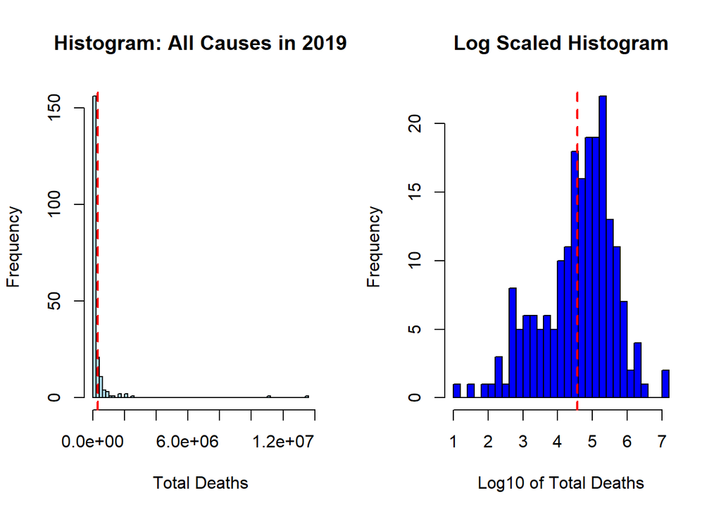

```r
#Histograms of
par(mfrow = c(1, 2))

# Histogram of the total deaths in 2019
hist(death_causes[death_causes$Year == 2019, "Allcauses"],
     breaks = 51,
     main = "Histogram: All Causes in 2019",
     xlab = "Total Deaths",
     col = "lightblue", border = "black")
abline(v = mean(death_causes[death_causes$Year == 2019, "Allcauses"], na.rm = TRUE), col = "red", lwd = 2, lty = 2)

# Histogram with log-scaled of the total deaths in 2019
log_allcauses <- log10(death_causes[death_causes$Year == 2019, "Allcauses"] + 1)
hist(log_allcauses,
     main = "Log Scaled Histogram",
     xlab = "Log10 of Total Deaths",
     col = "blue", border = "black", breaks = 41)
abline(v = mean(log_allcauses, na.rm = TRUE), col = "red", lwd = 2, lty = 2)
```

The first plot shows a notable number of outliers highly influence the distribution of total deaths. However, the distribution becomes much more balanced after applying a log transformation. This indicate that a much more balance distribution can be obtain with the exclude of extreme values or normalization . The natural outliers are countries with a too-large or too-small population; eliminating them from the data set is unreasonable. Instead, a normalization by dividing the number of deaths by population can improve the situation.

Therefore, we now combine the data with world’s population and GDP from World Bank.

## 2. Population Data

```r
library(tidyr)
population <- read.csv("population.csv", skip = 4)

#Change to pivot table
population <- population %>% pivot_longer(
    cols = starts_with("X"),
    names_to = "Year",
    names_prefix = "X",
    values_to = "Population"
  )

population$Year <- as.factor(population$Year)
population$Country.Code <- as.factor(population$Country.Code)
population <- as.data.frame(population)

#Checking rows in the main data that different from population data
unmatched_codes <- setdiff(death_causes$Code, population$Country.Code)
unmatched_rows <- death_causes %>% filter(Code %in% unmatched_codes)

cat("Missing value entity:", as.character(unique(unmatched_rows$Entity)))
```

```
## Missing value entity: Cook Islands Niue Taiwan Tokelau
```

```r
cat("Number of rows:", nrow(unmatched_rows))
```

```
## Number of rows: 120
```

Some entities do not have data in the population data set. Those are small states except Taiwan, and only 120 of the 6120 observations(about 2%). Our analysis will be sensitive to the population due to the normalization process. Therefore, we will exclude them from our data as they also do not significantly impact our models. However, an extended analysis with Taiwan may be conducted in the future when there is a better population data set.

```r
population <- population[c("Country.Code", "Year", "Population")]
death_causes <- death_causes %>% left_join(
  population, by = c("Code" = "Country.Code", "Year")) %>%
  filter(!is.na(Population))
```

## 3. GDP Data

We then continue to join the GDP per capita data into the main data set

```r
GDP_capita <- read.csv("GDP.csv", skip = 4)
GDP_capita <- GDP_capita %>% pivot_longer(
    cols = starts_with("X"),
    names_to = "Year",
    names_prefix = "X",
    values_to = "GDP"
  )

GDP_capita$Year <- as.factor(GDP_capita$Year)
GDP_capita$Country.Code <- as.factor(GDP_capita$Country.Code)

# Checking rows in death_causes that are different from GDP_capita dataframe
unmatched_codes_gdp <- setdiff(death_causes$Code, GDP_capita$Country.Code)
unmatched_rows_gdp <- death_causes %>% filter(Code %in% unmatched_codes_gdp)
cat("Number of unmatched rows:", nrow(unmatched_rows_gdp))
```

```
## Number of unmatched rows: 0
```

The number of entities in both data sets are match with each other.

```r
# Left join between death_causes and GDP_capita
GDP_capita <- GDP_capita[c("Country.Code", "Year", "GDP")]
death_causes <- death_causes %>% left_join( GDP_capita, by = c("Code" = "Country.Code", "Year"))
tryCatch({death_causes <- death_causes %>% rename(GDP_capita = GDP)
}, error = function(e) {cat("")})

# Entities with missing GDP per capita values
NA_rows <- death_causes[!complete.cases(death_causes$GDP_capita), ]
missing_gdp <- NA_rows %>% group_by(Entity) %>% summarise(missing_year_count = n())
missing_table <- missing_gdp[order(rank(as.numeric(missing_gdp$missing_year_count))), ]
kable(missing_table, format = "html") %>% scroll_box(height = "490px")
```

| Entity | missing_year_count |
| --- | --- |
| Mozambique | 1 |
| Belarus | 2 |
| Democratic Republic of Congo | 2 |
| Iran | 2 |
| Angola | 3 |
| Estonia | 3 |
| Serbia | 3 |
| Palestine | 4 |
| Latvia | 5 |
| Lithuania | 5 |
| Venezuela | 5 |
| Montenegro | 8 |
| San Marino | 9 |
| Afghanistan | 10 |
| Eritrea | 10 |
| American Samoa | 12 |
| Guam | 12 |
| Northern Mariana Islands | 12 |
| United States Virgin Islands | 12 |
| South Sudan | 22 |
| North Korea | 30 |

```r
sum(is.na(death_causes))
```

```
## [1] 172
```

The data shows 172 rows without GDP per capita values, about 3% of 6000 observations. Those missing values will be filled with linear interpolation and nearest available values. Due to the low proportion it have in the data set, the prediction is expected to have high accuracy and will not negative the performance.

```r
# Fill missing GDP values using linear interpolation for each country
library(zoo)
# Apply linear interpolation to fill in missing GDP per capita values
death_causes <- death_causes %>%
  group_by(Entity) %>%
  arrange(Year) %>%
  mutate(GDP_capita = zoo::na.approx(GDP_capita, na.rm = FALSE)) %>%
  ungroup()

# If some GDP per capita values are still missing, fill with nearest available value (forward or backward fill)
death_causes <- death_causes %>%
  group_by(Entity) %>%
  arrange(Year) %>%
  mutate(GDP_capita = zoo::na.locf(GDP_capita, na.rm = FALSE, fromLast = FALSE)) %>%
  mutate(GDP_capita = zoo::na.locf(GDP_capita, na.rm = FALSE, fromLast = TRUE)) %>%
  ungroup()

# Check for any remaining missing values
sum(is.na(death_causes$GDP_capita))
```

```
## [1] 30
```

In the data, North Korea do not has any GDP values to fill the GDP per capita values. Due to this nation’s political background, its other data also may no correct, therefore, this nation’s data will be exclude from the data set.

```r
# Drop all rows with missing GDP_capita values
death_causes <- death_causes %>% filter(!is.na(GDP_capita))
```

We then normalize the data to a data set name data_capita that only contain deaths data, population and GDP without Entity, Year and Code for further analysis.

```r
data_capita <- death_causes %>%  mutate(across(Outdoor.air.pollution:Iron.deficiency, ~ .x / Population))
data_capita$Allcauses <- data_capita$Allcauses/data_capita$Population
data_capita <- data_capita %>%  select(where(is.numeric)) %>%  select(-Population)

#GDP per capita to GDP total for death_causes
death_causes$GDP <- death_causes$GDP_capita * death_causes$Population
death_causes <- death_causes %>% select(-GDP_capita)
```

# III. Explonatory Data Analysis (EDA)

## 1. Distribution Analysis

We then look into the histogram of deaths in all causes per capita to analyse its distribution.

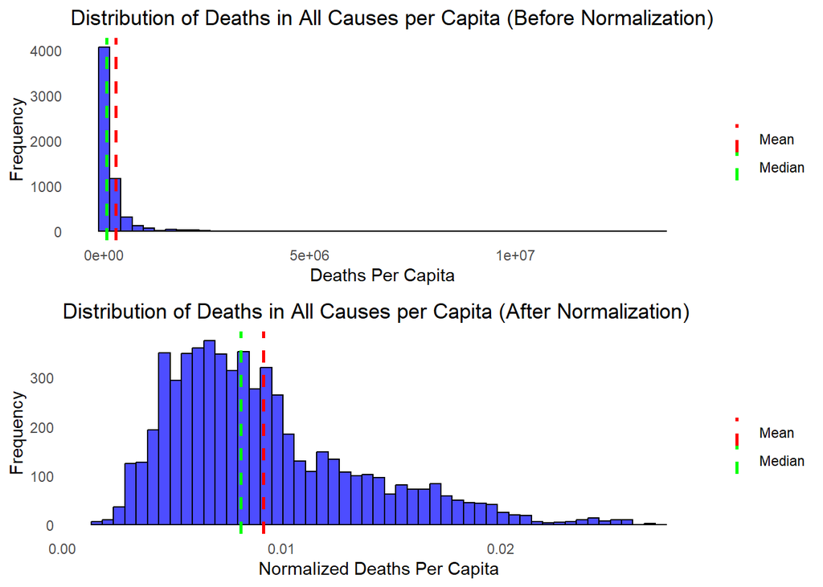

```r
library(ggplot2)
library(gridExtra)
# Convert the dataset to long format
data_long <- data_capita %>% pivot_longer(cols = everything(), names_to = "Variable", values_to = "Value")

# Plot before normalization
p1 <- ggplot(death_causes, aes(x = Allcauses)) +
  geom_histogram(bins = 51, fill = "blue", color = "black", alpha = 0.7) +
  labs(title = "Distribution of Deaths in All Causes per Capita (Before Normalization)",
       x = "Deaths Per Capita",
       y = "Frequency") +
  geom_vline(aes(xintercept = mean(Allcauses, na.rm = TRUE), color = "Mean"),
             linetype = "dashed", linewidth = 1) +  # Dashed line for mean
  geom_vline(aes(xintercept = median(Allcauses, na.rm = TRUE), color = "Median"),
             linetype = "dashed", linewidth = 1) +  # Dashed line for median
  scale_color_manual(name = "", values = c(Mean = "red", Median = "green")) +
  theme_minimal() +
  theme(panel.grid.major = element_blank(), panel.grid.minor = element_blank())

# Plot after normalization
p2 <- ggplot(data_capita, aes(x = Allcauses)) +
  geom_histogram(bins = 51, fill = "blue", color = "black", alpha = 0.7) +
  labs(title = "Distribution of Deaths in All Causes per Capita (After Normalization)",
       x = "Normalized Deaths Per Capita",
       y = "Frequency") +
  geom_vline(aes(xintercept = mean(Allcauses, na.rm = TRUE), color = "Mean"),
             linetype = "dashed", linewidth = 1) +  # Dashed line for mean
  geom_vline(aes(xintercept = median(Allcauses, na.rm = TRUE), color = "Median"),
             linetype = "dashed", linewidth = 1) +  # Dashed line for median
  scale_color_manual(name = "", values = c(Mean = "red", Median = "green")) +
  theme_minimal() +
  theme(panel.grid.major = element_blank(), panel.grid.minor = element_blank())
grid.arrange(p1, p2, ncol = 1)
```

While the histogram of the normalized data set shows extreme values have already been treated. This indicate the data has a right skewed distribution, showing the majority of nations have a low death rate. A further tranfomation will need to be conducted in modelling data preparation after labelling step.

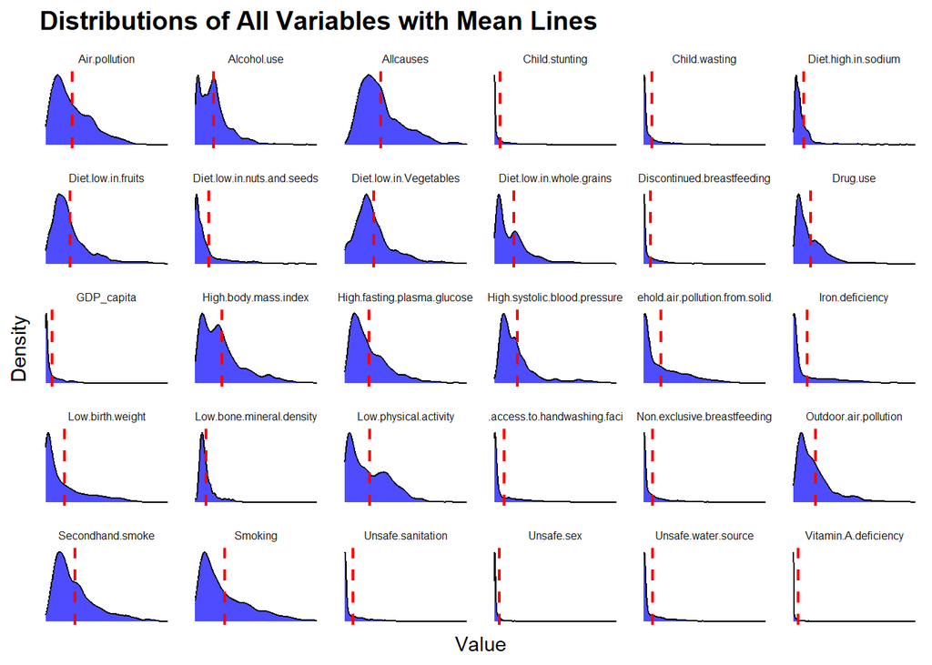

```r
# Convert the dataset to long format
data_long <- data_capita %>%
  pivot_longer(cols = everything(), names_to = "Variable", values_to = "Value")

# Calculate means for each variable
means <- data_long %>%
  group_by(Variable) %>%
  summarise(Mean = mean(Value, na.rm = TRUE))

# Plot faceted density plots with mean lines for each variable
ggplot(data_long, aes(x = Value)) +
  geom_density(fill = "blue", color = "black", alpha = 0.7) +
  geom_vline(data = means, aes(xintercept = Mean), color = "red", linetype = "dashed", size = 0.8) +
  facet_wrap(~ Variable, scales = "free") +
  labs(title = "Distributions of All Variables with Mean Lines",
       x = "Value",
       y = "Density") +
  theme_minimal() +
  theme(panel.grid.major = element_blank(),
        panel.grid.minor = element_blank(),
        strip.text = element_text(size = 6),
        axis.text = element_blank(),
        plot.title = element_text(size = 14, face = "bold"))
```

The histogram shows that the majority of variables have right-skewed skewed distribution. Therefore, a log transformation will be conducted except with the target variables since it will be labelled with a mean value. This also mean that most of that nation have lower morality rates that the average, which is reasonable with the real world senario.

## 2. Correlation

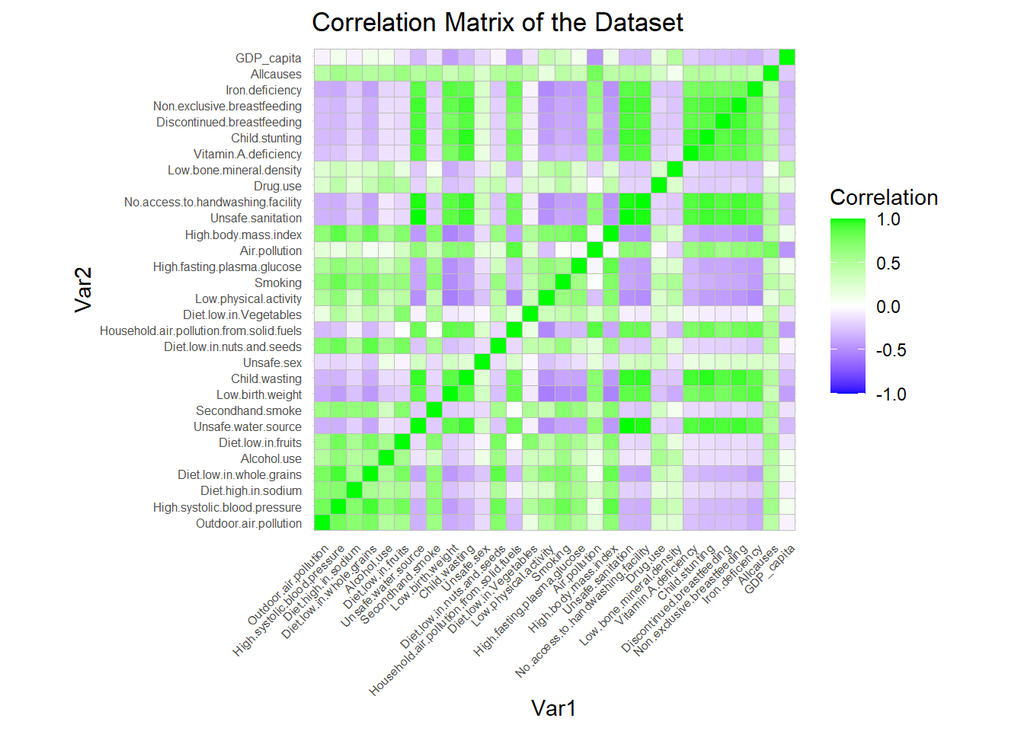

```r
library(reshape2)
correlation_matrix_all <- cor(data_capita, use = "complete.obs")
melted_corr_all <- melt(correlation_matrix_all)
ggplot(data = melted_corr_all, aes(x=Var1, y=Var2, fill=value)) +
  geom_tile(color = "gray") +  # Add black borders between cells
  scale_fill_gradient2(low = "blue", high = "green", mid = "white",
                       midpoint = 0, limit = c(-1,1), space = "Lab",
                       name="Correlation") +  theme_minimal() +
  theme(axis.text.x = element_text(angle = 45, vjust = 1, size = 6, hjust = 1),
        axis.text.y = element_text(size = 6)) +
  coord_fixed() +  ggtitle("Correlation Matrix of the Dataset")
```

The matrix shows multiple strong correlation zones, both in negative and positive relationships; this indicates the clustering model will have significant results from this data set. To have more information, the discussion about those relationships continues in the clustering part, where the clusters will be more clear. High correlations should also be considered a potential problem during the modelling process, and further analysis of Multi-collinearity will be conducted to select the most suitable methods.

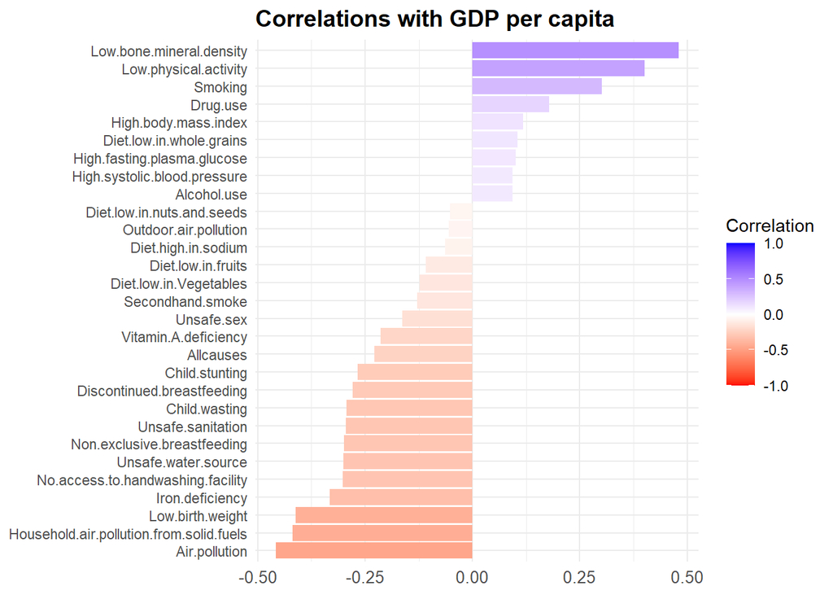

```r
# The correlation matrix for all causes
cor_matrix2 <- cor(data_capita, use = "complete.obs")

# Correlations with Low.birth.weight
cor_low_birth_weight_2 <- cor_matrix2["GDP_capita", ]
cor_df_2 <- data.frame(Variable = names(cor_low_birth_weight_2), Correlation = cor_low_birth_weight_2)
cor_df_2 <- cor_df_2[cor_df_2$Variable != "GDP_capita", ]
# Sort the variables by absolute correlation for better visualization
cor_df_2 <- cor_df_2 %>% arrange(desc(abs(Correlation)))

ggplot(cor_df_2, aes(x = reorder(Variable, Correlation), y = Correlation, fill = Correlation)) +
  geom_bar(stat = "identity") +
  scale_fill_gradient2(low = "red", high = "blue", mid = "white",
                       midpoint = 0, limit = c(-1, 1), space = "Lab",
                       name = "Correlation") +  coord_flip() +  theme_minimal() +
  theme(
    axis.title.x = element_blank(),
    axis.title.y = element_blank(),
    axis.text.x = element_text(size = 10),
    plot.title = element_text(size = 14, face = "bold")
  ) +  ggtitle("Correlations with GDP per capita")
```

This plot shows the correlations between GDP per capita and causes of death.

- Positive correlations (blue): Factors like low physical activity, low bone mineral density, smoking, and high body mass index are more prevalent with higher GDP per capita countries.
- Negative correlations (red): Factors like unsafe water sources, household air pollution, low birth weight, and child wasting are more prevalent with lower GDP per capita countries. This indicating they are associated with poorer, less developed nations.

## 3. Target Variable Analysis

### a. Relationship with GDP per Capita

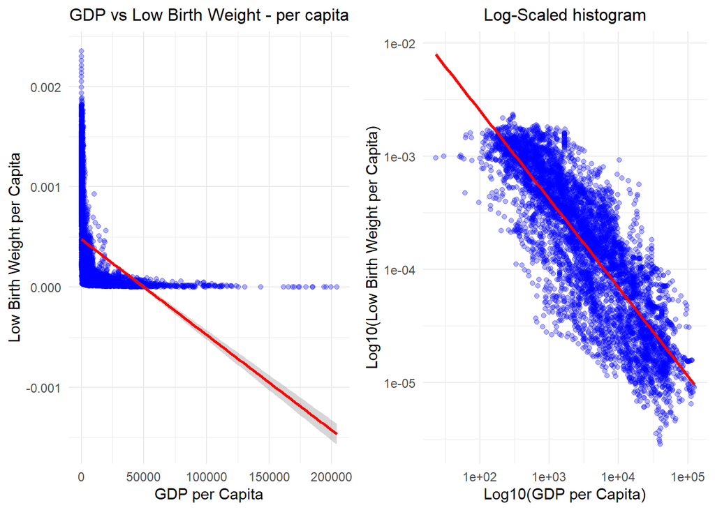

```r
# Normal scale plot with custom axis titles
plot1 <- ggplot(data_capita, aes(x = GDP_capita, y = Low.birth.weight)) +
  geom_point(color = "blue", alpha = 0.3) +
  geom_smooth(method = "lm", se = TRUE, color = "red") +
  labs(
    title = "GDP vs Low Birth Weight - per capita",
    x = "GDP per Capita",
    y = "Low Birth Weight per Capita"
  ) + theme_minimal() + theme(
    plot.title = element_text(size = 12, hjust = 0.5),
    strip.text = element_text(size = 8)
  )

# Log-scaled plot with custom axis titles
plot2 <- ggplot(data_capita %>% filter(GDP_capita > 0, Low.birth.weight > 0), aes(x = GDP_capita, y = Low.birth.weight)) +
  geom_point(color = "blue", alpha = 0.3) +
  geom_smooth(method = "lm", se = TRUE, color = "red") +
  labs(
    title = "Log-Scaled histogram",
    x = "Log10(GDP per Capita)",
    y = "Log10(Low Birth Weight per Capita)"
  ) +
  theme_minimal() +  theme(
    plot.title = element_text(size = 12, hjust = 0.5),
    strip.text = element_text(size = 8)
  ) + scale_x_log10() + scale_y_log10()

grid.arrange(plot1, plot2, ncol = 2)
```

The normal scale plot shows no linear relationship between GDP per capita and deaths by low birth weight per capita. There is also a high concentration of data points at low GDP levels, where the incidence of deaths by low birth weight per capita is relatively high.

The log-transformed plot shows a much clearer linear relationship between the log of GDP per capita and the log of low birth weight. This indicates that a a logarithmic relationship exists. Additionally, the death rate in low birth weight decreases as GDP per capita increases in log scale. This relationship matches with the distribution in the normal scale plot.

This suggests that a log transformation in the model may create significant improvement; this conclusion must be tested in the following steps.

### b. Correlation with Other Variables

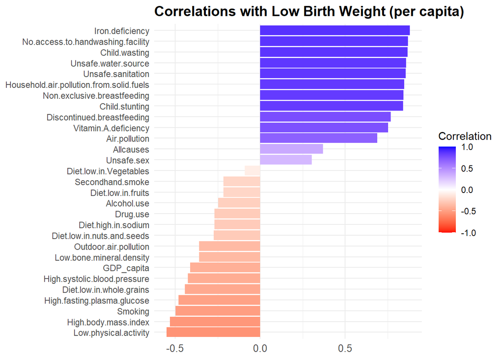

```r
cor_matrix <- cor(data_capita, use = "complete.obs")
cor_low_birth_weight <- cor_matrix["Low.birth.weight", ]
cor_df <- data.frame(Variable = names(cor_low_birth_weight), Correlation = cor_low_birth_weight)
cor_df <- cor_df[cor_df$Variable != "Low.birth.weight", ]
# Sort the variables by absolute correlation for better visualization
cor_df <- cor_df %>% arrange(desc(abs(Correlation)))

ggplot(cor_df, aes(x = reorder(Variable, Correlation), y = Correlation, fill = Correlation)) +
  geom_bar(stat = "identity") +
  scale_fill_gradient2(low = "red", high = "blue", mid = "white",
                       midpoint = 0, limit = c(-1, 1), space = "Lab",
                       name = "Correlation") +
  coord_flip() +  theme_minimal() + theme(
    axis.title.x = element_blank(),
    axis.title.y = element_blank(),
    axis.text.x = element_text(size = 10),
    plot.title = element_text(size = 14, face = "bold")
  ) +  ggtitle("Correlations with Low Birth Weight (per capita)")
```

The correlations plot shows that there are two groups of variables, a positive and negative correlation. The negative group can explain that most of the death causes are related to high-income nation attributes, like low physical activity, high fasting plasma glucose, and a diet high in sodium.

Meanwhile, the positive group is related to low-income nations, such as iron deficiency, unsafe water sources, and vitamin A deficiency.

While most of the negative correlations are low correlations (between -0.5 and 0), the positive opposite is mostly higher than 0.5, indicating a strong relationship between the death rate by low birth weight and the positive correlation group.

# IV. Classification models

## 1. Modelling’s Data Preparation

### a. Labelling and log tranformation

Since classification is a supervised learning, the target variable Low.birth.weight will be labeled as “High” and “Low”. This will be done by using the mean value of the Low.birth.weight variable as a threshold.

```r
#Labelling using mean
#Remove Allcauses as unnecessary additional variable
causes_labled <- data_capita %>% select(-Allcauses)
index <- mean(data_capita$Low.birth.weight, na.rm = TRUE)
causes_labled$Low.birth.weight <- as.factor(ifelse(data_capita$Low.birth.weight >= index, "High", "Low"))
summary(causes_labled$Low.birth.weight)
```

```
## High  Low
## 2060 3910
```

Low.birth.weight in labelled data has “High” as 34.5% (2060 observations) and “Low” as 65.5% (3910 observations). This means that “Low” is the highest frequent value. Therefore, the Null model will use observations that have a “Low” value for its training data set.

This also indicates that the data set is imbalanced. Due to this imbalance, the model may become biased toward instances with ‘Low’ values in the target variable. This imbalance is a critical factor to consider during our modeling process. We will need to evaluate the model’s performance carefully, focusing on metrics such as precision, recall, and F1-score. If the model performs poorly due to the imbalance, we may need to apply different techniques to mitigate bias.

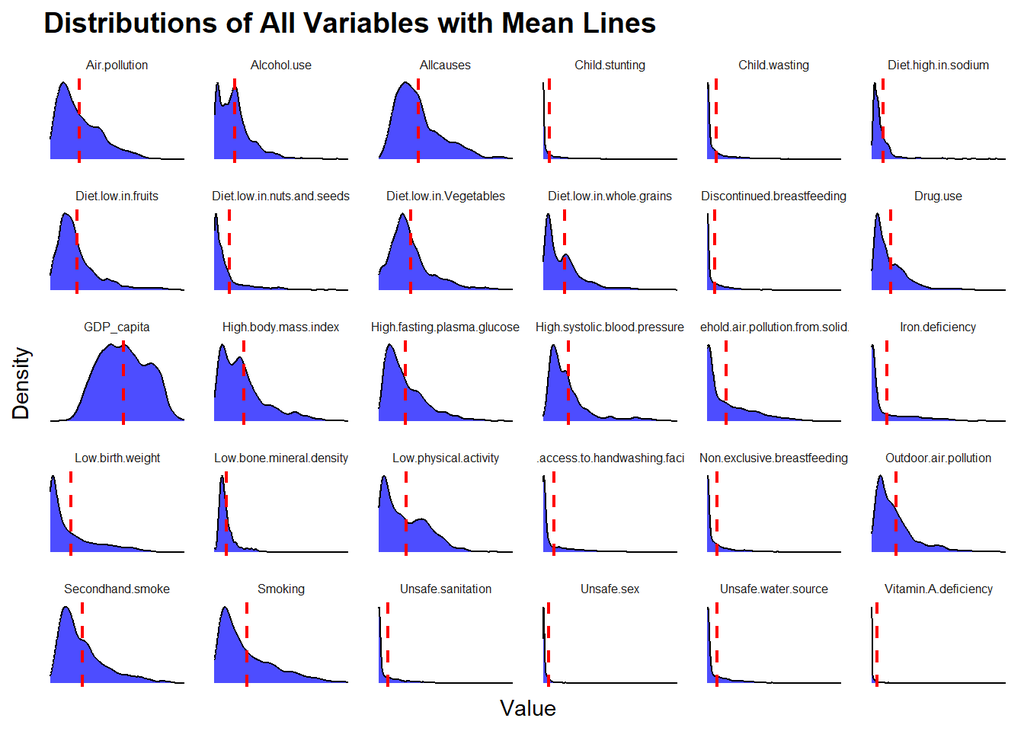

```r
#Log tranformation the explonatory data
numeric_features <- setdiff(names(data_capita), "Low.birth.weight")
data_capita[numeric_features] <- lapply(data_capita[numeric_features], function(x) log10(x + 1))

# Convert the dataset to long format
data_long2 <- data_capita %>%
  pivot_longer(cols = everything(), names_to = "Variable", values_to = "Value")

# Calculate means for each variable
means2 <- data_long2 %>%
  group_by(Variable) %>%
  summarise(Mean = mean(Value, na.rm = TRUE))

# Plot faceted density plots with mean lines for each variable
ggplot(data_long2, aes(x = Value)) +
  geom_density(fill = "blue", color = "black", alpha = 0.7) +
  geom_vline(data = means2, aes(xintercept = Mean), color = "red", linetype = "dashed", size = 0.8) +
  facet_wrap(~ Variable, scales = "free") +
  labs(title = "Distributions of All Variables with Mean Lines",
       x = "Value",
       y = "Density") +
  theme_minimal() +
  theme(panel.grid.major = element_blank(),
        panel.grid.minor = element_blank(),
        strip.text = element_text(size = 6),
        axis.text = element_blank(),
        plot.title = element_text(size = 14, face = "bold"))
```

The log transformation did improve some variable’ distributions, but it is not much. The model training will have to conduct with skewed data.

### b. Detect Perfect Separation

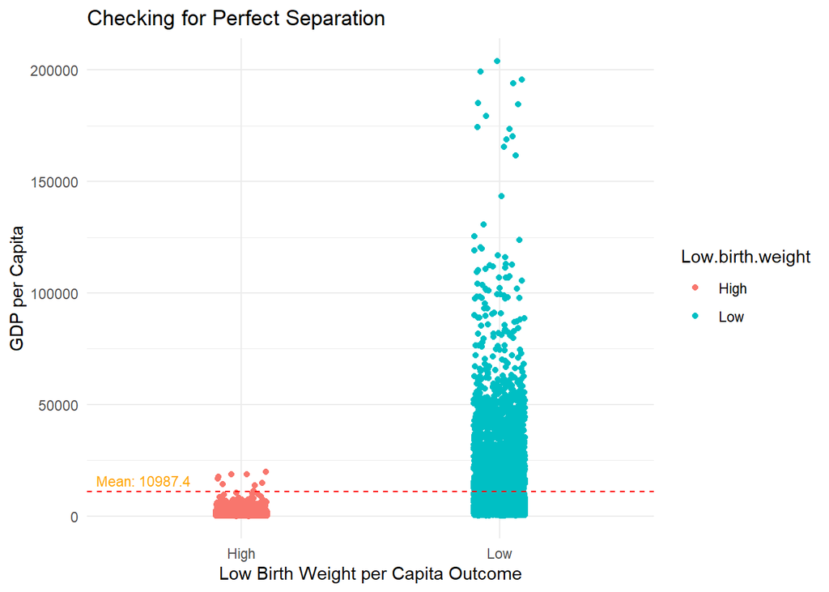

```r
# Example of plotting GDP vs Low Birth Weight to check for separation
mean_gdp <- mean(causes_labled$GDP_capita, na.rm = TRUE)

ggplot(causes_labled, aes(y = GDP_capita, x = Low.birth.weight, color = Low.birth.weight)) +
  geom_jitter(width = 0.1, height = 0.1) +
  geom_hline(yintercept = mean_gdp, linetype = "dashed", color = "red") +
  labs(title = "Checking for Perfect Separation",
       y = "GDP per Capita",
       x = "Low Birth Weight per Capita Outcome") +
  theme_minimal() +
 annotate("text", x = -Inf, y = mean_gdp, label = paste("Mean:", round(mean_gdp, 1)),
           hjust = -0.1, vjust = -0.5, color = "orange", size = 3)
```

High low-birth-weight outcomes are tightly clustered in countries with GDP per capita lower than the average, whereas such outcomes are rare in countries with higher GDP per capita.

Specifically, nations with GDP per Capita lower than the average tend to have High Low Birth Weight mortality, while countries with higher GDP per Capita tend to be the opposite.

The naive Bayesian model or KNN model would be a better solution. While the KNN model is resource intensive, Naive Bayesian is a better choice for the first try of modelling as it is lighter and faster and suits a high number of variable cases. However, it also needs an assumption of feature independence, which may negatively impact the performance of the model if it is False.

### c. Detect Zero Variance Predictors

```r
library(caret)
# Check for near-zero variance predictors
nzv <- nearZeroVar(causes_labled)
nzv_predictors <- names(causes_labled)[nzv]
cat("Near-zero variance predictors:", length(nzv_predictors))
```

```
## Near-zero variance predictors: 0
```

Since there are no near-zero variance predictors, no transformation needs to be conducted.

### d. Detect Multi-collinearity

```r
#Using Logis model and Variance Inflation Factor (VIF) to check Multi-collinearity
library(car)
model <- glm(Low.birth.weight ~ ., data = causes_labled, family = binomial)
# Calculate VIF values for the predictors
vif_values <- vif(model)
# Print the VIF values
cat("Number of variables that have VIF higher than 5:", length(vif_values[vif_values > 5]))
```

```
## Number of variables that have VIF higher than 5: 21
```

```r
cat("Number of variables that have VIF higher than 10:", length(vif_values[vif_values > 10]))
```

```
## Number of variables that have VIF higher than 10: 12
```

- There are 21 variables have moderate multi-collinearity (VIF > 5)..
- There are 12 variables have high multi-collinearity (VIF > 10).

This again mean that linear models, such as logistic regression, is unsuitable for this data set.

### e. Data Splitting

The test and train data split will use the 80/20 ratio. Calibration will using 10 fold Cross Validation method.

```r
# Set a seed for reproducibility
set.seed(161094)
# Create the train-test split (80/20)
train_index <- createDataPartition(causes_labled$Low.birth.weight, p = 0.8, list = FALSE)
dTrain <- causes_labled[train_index, ]
dTest <- causes_labled[-train_index, ]
```

# 2. Null model

To analyse the performance, a custom function will be used.

```r
library(pROC)

# Performance test with Accuracy, CI, PValue, F1_Score, Kappa, AUC, McNemar_PValue, Precision, and Recall.
Performance <- function(predicted_set, predicted_prob, true_set = dTest$Low.birth.weight,
                        Positive = "High", Negative = "Low") {
  # Calculate Confusion Matrix
  conf_matrix <- confusionMatrix(predicted_set, true_set)

  # Extract metrics from confusion matrix
  accuracy <- conf_matrix$overall["Accuracy"]
  accuracy_ci <- conf_matrix$overall[c("AccuracyLower", "AccuracyUpper")]
  accuracy_pval <- conf_matrix$overall["AccuracyPValue"]
  kappa <- conf_matrix$overall["Kappa"]
  precision <- conf_matrix$byClass["Pos Pred Value"]  # Precision
  recall <- conf_matrix$byClass["Sensitivity"]        # Recall
  f1_score <- 2 * (precision * recall) / (precision + recall)  # F1 Score

  # AUC Calculation:
  roc_obj <- roc(true_set, predicted_prob, levels = c(Negative, Positive))
  auc_value <- auc(roc_obj)

  # McNemar's Test Calculation
  mcnemar_test <- mcnemar.test(table(true_set, predicted_set))
  mcnemar_pval <- mcnemar_test$p.value

  # Return the results as a list, including Precision and Recall
  result <- list(
    Accuracy = accuracy,
    Accuracy_CI_Lower = accuracy_ci[1],
    Accuracy_CI_Upper = accuracy_ci[2],
    Accuracy_PValue = accuracy_pval,
    F1_Score = f1_score,
    Precision = precision,
    Recall = recall,
    Kappa = kappa,
    AUC = auc_value,
    McNemar_PValue = mcnemar_pval
  )
return(result)
}
```

As “Low” value in Low.birth.weight is the majority category, it can used to create a low performance model as Null model.

```r
# Print confusion matrix and performance metrics
null_model_prediction <- as.factor(rep("Low", nrow(dTest)))
conf_matrix <- confusionMatrix(null_model_prediction, dTest$Low.birth.weight)
print(conf_matrix)
```

```
## Confusion Matrix and Statistics
##
##           Reference
## Prediction High Low
##       High    0   0
##       Low   412 782
##
##                Accuracy : 0.6549
##                  95% CI : (0.6272, 0.6819)
##     No Information Rate : 0.6549
##     P-Value [Acc > NIR] : 0.5134
##
##                   Kappa : 0
##
##  Mcnemar's Test P-Value : <2e-16
##
##             Sensitivity : 0.0000
##             Specificity : 1.0000
##          Pos Pred Value :    NaN
##          Neg Pred Value : 0.6549
##              Prevalence : 0.3451
##          Detection Rate : 0.0000
##    Detection Prevalence : 0.0000
##       Balanced Accuracy : 0.5000
##
##        'Positive' Class : High
##
```

The accuracy of the model on test data set is 65%, and the AUC is 0.5, meaning it is a Null model as the model is equivalent to random guessing.

# 3. Decision Tree Model

## a. Single Variable Model

The model will be trainned with 10-fold cross-validation and the single variable will be GDP per capita.

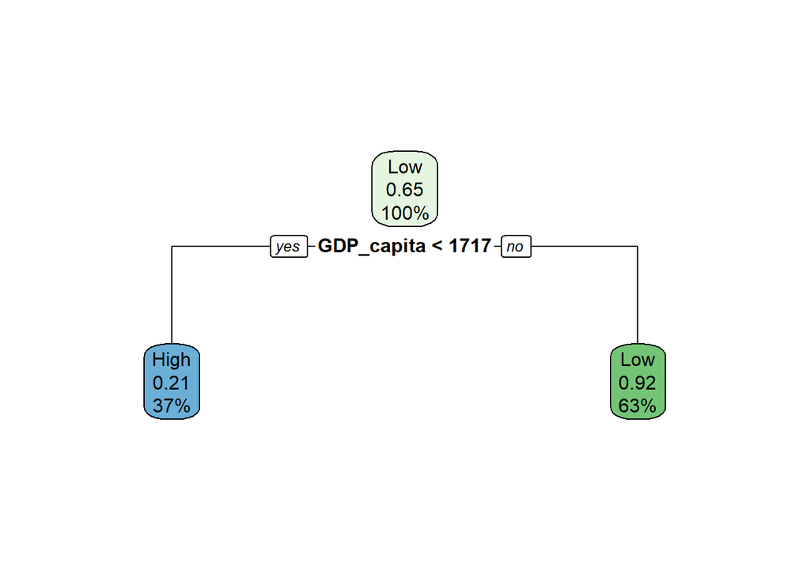

```r
library(rpart.plot)
# Train model with 10-fold cross-validation
train_control <- trainControl(method = "cv", number = 10)
model_dtree_1 <- train(Low.birth.weight ~ GDP_capita,
                        data = dTrain,
                        method = "rpart",
                        trControl = train_control,
                        tuneLength = 10)
#Plotting Decision Tree
rpart.plot(model_dtree_1$finalModel)
```

```r
#Performance check with train set
predicted_dtree_1 <- predict(model_dtree_1$finalModel, newdata = dTest, type = "class")
prob_dtree_1 <- predict(model_dtree_1$finalModel, newdata = dTest, type = "prob")[, "High"]
performance_dtree_1 <- Performance(predicted_dtree_1, prob_dtree_1)
print.summaryDefault(performance_dtree_1 )
```

```
##          Accuracy Accuracy_CI_Lower Accuracy_CI_Upper   Accuracy_PValue
##            0.8618            0.8409            0.8809         3.878e-59
##          F1_Score         Precision            Recall             Kappa
##            0.8061            0.7813            0.8325            0.6989
##               AUC    McNemar_PValue
##            0.8549           0.04296
```

The model performs well overall, with an accuracy of 86.2% and 95% CI : (0.84, 0.88), significantly higher than the no-information rate (65.5%), supported by a P-value < 3.878e-59, showing that the accuracy is not due to random chance.

- Precision = 0.7813 and Recall = 0.8325 are not an excellent performance but still a good values.
- F1 Score: 0.8 is a good balance between precision and recall. Moreover, the other index also showed a good performance, around 0.8. AUC is 0.85, which also shows that this is a good model.
- The Kappa statistic of 0.7 indicates a substantial agreement; however, it still does not meet the expectations of this project.
- Meanwhile, McNemar’s test P = 0.043 is below the 0.05 threshold, indicating a significant imbalance in classification errors. This suggests the model might be biased toward one class.

## b. Multiple Variables Model

```r
# Set up 10-fold cross-validation
control <- rfeControl(functions = rfFuncs, method = "cv", number = 10)  # 10-fold cross-validation

# Perform RFE to select features
rfe_result_rfe <- rfe(dTrain[, -which(names(dTrain) == "Low.birth.weight")],
                  dTrain$Low.birth.weight,
                  sizes = c(1:10),
                  rfeControl = control)
```

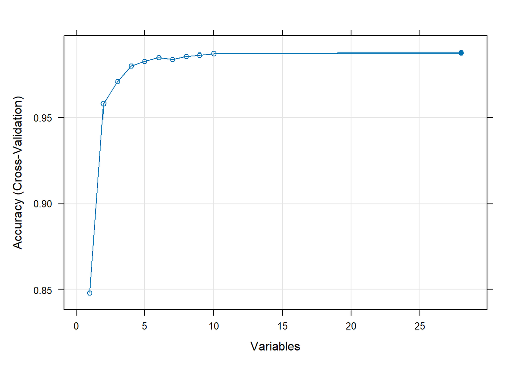

```r
# Plot RFE results
plot(rfe_result_rfe, type = c("g", "o"))
```

```r
rfe_result_rfe$results
```

```
##    Variables  Accuracy     Kappa  AccuracySD    KappaSD
## 1          1 0.8481452 0.6632884 0.109127496 0.24330994
## 2          2 0.9579138 0.9068952 0.008352667 0.01821401
## 3          3 0.9706872 0.9350076 0.005837508 0.01311268
## 4          4 0.9796904 0.9549989 0.006697508 0.01489580
## 5          5 0.9824119 0.9610165 0.008148211 0.01808964
## 6          6 0.9847153 0.9661129 0.006005847 0.01342747
## 7          7 0.9836671 0.9638453 0.007106099 0.01580949
## 8          8 0.9853421 0.9675372 0.006085419 0.01353114
## 9          9 0.9859714 0.9689508 0.007255806 0.01615955
## 10        10 0.9868078 0.9708012 0.006773054 0.01503973
## 11        28 0.9874359 0.9721709 0.007322947 0.01626543
```

The plot showing that k = 28 is the best k. However, k from 6 to 10 also shows a good performance with insignificance gap. As k = 10 giving a balance betweem performance and the risk of overfitting due to complex model with high k, the model will continue to be train using that k to reduce the compute

```r
# Select the best features based on RFE results
selected_features_rfe <- predictors(rfe_result_rfe)[1:10]
selected_features_rfe
```

```
##  [1] "Child.wasting"               "Diet.high.in.sodium"
##  [3] "Unsafe.sex"                  "Alcohol.use"
##  [5] "Vitamin.A.deficiency"        "Non.exclusive.breastfeeding"
##  [7] "Child.stunting"              "Diet.low.in.nuts.and.seeds"
##  [9] "Diet.low.in.Vegetables"      "Drug.use"
```

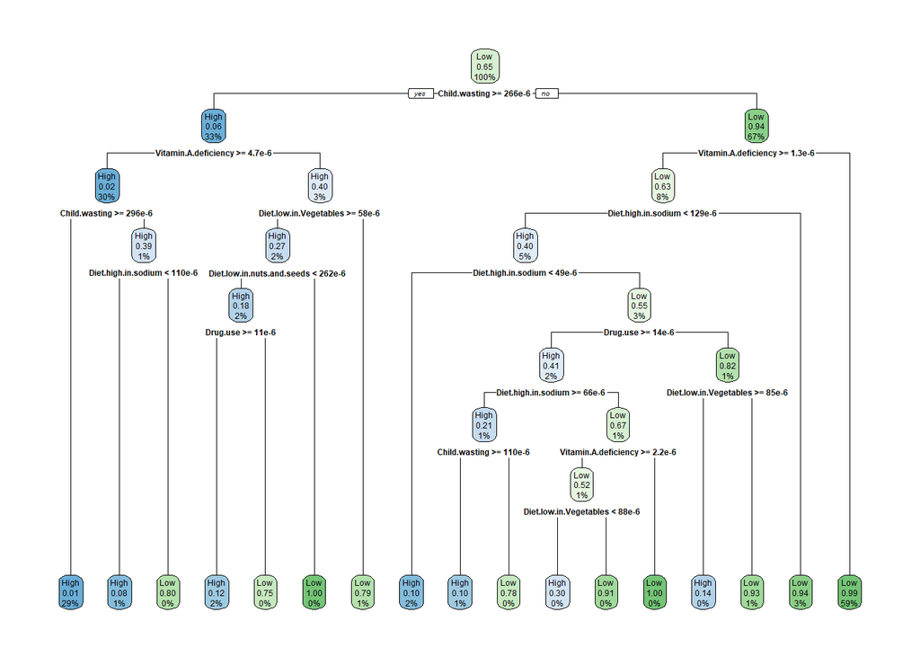

```r
# Create the formula using the selected features
formula_rfe <- as.formula(paste("Low.birth.weight ~", paste(selected_features_rfe, collapse = " + ")))

# Train the decision tree model with 10-fold cross-validation
train_control <- trainControl(method = "cv", number = 10)
model_dtree_2 <- train(formula_rfe,
                         data = dTrain,
                         method = "rpart",
                         trControl = train_control,
                         tuneLength = 10)  # Try 10 different values for the complexity parameter (cp)
#Decision Tree model plotting
rpart.plot(model_dtree_2$finalModel)
```

```r
#Performance check with train set for Decision Tree Model 2
predicted_dtree_2 <- predict(model_dtree_2$finalModel, newdata = dTest, type = "class")
prob_dtree_2 <- predict(model_dtree_2$finalModel, newdata = dTest, type = "prob")[, "High"]
performance_dtree_2 <- Performance(predicted_dtree_2, prob_dtree_2)
print.summaryDefault(performance_dtree_2)
```

```
##          Accuracy Accuracy_CI_Lower Accuracy_CI_Upper   Accuracy_PValue
##             0.964            0.9518            0.9738        6.425e-153
##          F1_Score         Precision            Recall             Kappa
##            0.9481            0.9424            0.9539            0.9206
##               AUC    McNemar_PValue
##            0.9796            0.5419
```

The model performs outstanding overall, with an accuracy of 96.4% and a 95% CI (95.18%, 97.38%), significantly higher than the no-information rate, supported by a P-value of 6.425e-153, showing that the accuracy is not due to random chance.

# 4. Naive Bayes Model

## a. Single Variable Model

```r
library(naivebayes)
# Set up train control for 10-fold cross-validation
train_control <- trainControl(method = "cv", number = 10)

model_bayes_1 <- train(Low.birth.weight ~ GDP_capita,
                       data = dTrain,
                       method = "naive_bayes",
                       tuneLength = 99)
```

```r
#Performance check with train set for Bayes Model 1
predicted_bayes_1 <- predict(model_bayes_1$finalModel, newdata = dTest, type = "class")
prob_bayes_1 <- predict(model_bayes_1$finalModel, newdata = dTest, type = "prob")[, "High"]
performance_bayes_1 <- Performance(predicted_bayes_1, prob_bayes_1)
print.summaryDefault(performance_bayes_1)
```

```
##          Accuracy Accuracy_CI_Lower Accuracy_CI_Upper   Accuracy_PValue
##            0.8559            0.8347            0.8754         1.358e-55
##          F1_Score         Precision            Recall             Kappa
##            0.8023             0.762            0.8471            0.6895
##               AUC    McNemar_PValue
##            0.9239         0.0006009
```

The model performs well overall, with an accuracy of 85.59% and 95% CI: (83.47%, 87.54%), significantly higher than the no-information rate (65.49%), supported by a P-value of 1.358e-55, showing that the accuracy is not due to random chance.

- Precision = 0.762 and Recall = 0.8471 are not an excellent performance but still a good values.
- F1 Score: 0.8023 is a good balance between precision and recall. Moreover, the other index also showed a good performance, around 0.8. AUC is 0.9239, which also shows that this is a good model.
- The Kappa statistic of 0.6895 indicates a substantial agreement; however, it still does not meet the expectations of this project.
- McNemar’s test P-value = 0.0006 is below the 0.05 threshold, indicating a significant imbalance in classification errors. This suggests the model might be biased toward one class.

```r
#LIME Function set up
#(Benesty 2022)
# LIME Function setup
library(lime)
apply_lime <- function(train_data, test_data, model, target_variable) {
  # Remove the target variable column when creating the explainer
  explainer <- lime(train_data[, -which(names(train_data) == as.character(target_variable))], as_classifier(model))

  # Select the first 6 instances to explain from the test data
  instances_to_explain <- test_data[1:6, -which(names(test_data) == as.character(target_variable))]

  # Generate explanations for 1 label using 5 features
  explanation <- explain(instances_to_explain, explainer, n_labels = 1, n_features = 5)

  # Plot the explanations
  plot_features(explanation) +
    theme(
      legend.text = element_text(size = 6),
      plot.title = element_text(size = 6, face = "bold"),
      axis.text = element_text(size = 5),
      axis.title = element_text(size = 5),
      strip.text = element_text(size = 4)
    )
}
```

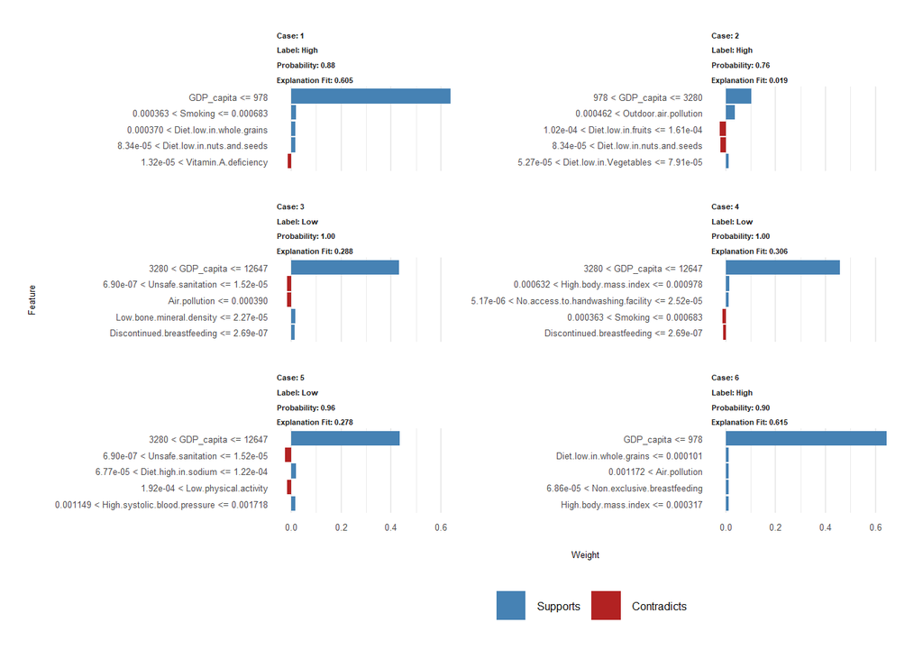

```r
#LIME
apply_lime(dTrain, dTest, model_bayes_1, "Low.birth.weight")
```

- Explanation fit up to 0.6 in Case 1 and 6 means that the local model of LIME is able to explain a moderate portion of the original model’s behavior around these specific instances. While the fit isn’t perfect, it’s strong enough to provide a fairly reliable interpretation.
- In Case 3, 4, and 5, the lower explanation fit (around 0.3) suggests that the local model has more difficulty approximating the behavior of the original model. The LIME explanation is less reliable in these cases since it only captures about 30% of the original model’s decision-making process.
- However, despite the low explanation fit, the probability of the predictions in LIME plot are high for all cases. This means that the original model is confident in its predictions and local model can’t fully capture the complexity of how the original model made those decisions.

## b. Multiple Variable Model

```r
# Set up train control for 10-fold cross-validation
control <- rfeControl(functions = nbFuncs, method = "cv", number = 10)
# Perform RFE to select features
rfe_result_2_rfe <- rfe(dTrain[, -which(names(dTrain) == "Low.birth.weight")],
                  dTrain$Low.birth.weight,
                  sizes = c(1:10),
                  rfeControl = control)
```

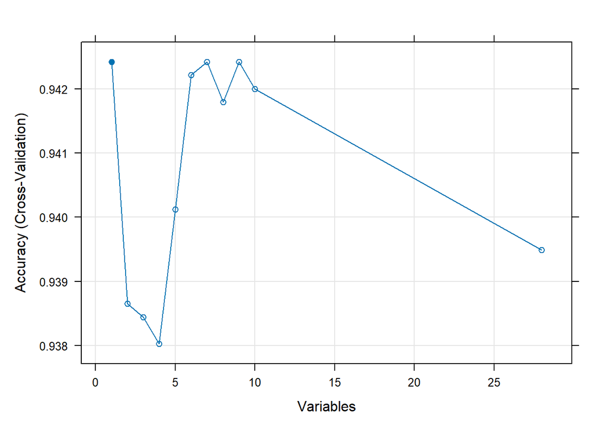

```r
# Plot RFE results
plot(rfe_result_2_rfe, type = c("g", "o"))
```

```r
rfe_result_2_rfe$results
```

```
##    Variables  Accuracy     Kappa  AccuracySD    KappaSD
## 1          1 0.9424225 0.8703694 0.007837508 0.01781358
## 2          2 0.9386529 0.8638275 0.009661987 0.02138449
## 3          3 0.9384410 0.8638092 0.008099515 0.01786109
## 4          4 0.9380270 0.8624957 0.008815062 0.01921724
## 5          5 0.9401195 0.8673934 0.008254557 0.01804650
## 6          6 0.9422133 0.8722140 0.008936457 0.01954598
## 7          7 0.9424212 0.8729716 0.009831464 0.02137331
## 8          8 0.9417914 0.8716032 0.009358058 0.02026237
## 9          9 0.9424195 0.8730037 0.010826524 0.02356409
## 10        10 0.9420010 0.8722375 0.009575277 0.02093389
## 11        28 0.9394901 0.8668442 0.010691919 0.02322937
```

The plot shows that k = 1 is the best k with low accuracy SD and high accuracy. As k = 6 and k = 9 are almost similar in performance, k = 6 will be selected as a balance option. We will check what features in each cases for a conclusion.

```r
library(caret)
# Define control using Naive Bayes-specific functions
control <- rfeControl(functions = nbFuncs, method = "cv", number = 10) # 10-fold cross-validation
# Perform RFE for k = 1
rfe_result_1 <- rfe(dTrain[, -which(names(dTrain) == "Low.birth.weight")],
                  dTrain$Low.birth.weight,
                  sizes = 1, # number of variables
                  rfeControl = control)
selected_features_1 <- predictors(rfe_result_1)
# Perform RFE for k = 6
rfe_result_6 <- rfe(dTrain[, -which(names(dTrain) == "Low.birth.weight")],
                  dTrain$Low.birth.weight,
                  sizes = 6, # number of variables
                  rfeControl = control)
selected_features_6 <- predictors(rfe_result_6)
# Perform RFE for k = 9
rfe_result_9 <- rfe(dTrain[, -which(names(dTrain) == "Low.birth.weight")],
                  dTrain$Low.birth.weight,
                  sizes = 9, # number of variables
                  rfeControl = control)
selected_features_9 <- predictors(rfe_result_9)

cat("Selected features for k = 1:", selected_features_1, "\n")
```

```
## Selected features for k = 1: Child.wasting
```

```r
cat("Selected features for k = 6:", selected_features_6, "\n")
```

```
## Selected features for k = 6: Child.wasting Unsafe.water.source Child.stunting Vitamin.A.deficiency Unsafe.sanitation Iron.deficiency
```

```r
cat("Selected features for k = 9:", selected_features_9, "\n")
```

```
## Selected features for k = 9: Child.wasting Unsafe.water.source Child.stunting Vitamin.A.deficiency Unsafe.sanitation Iron.deficiency Non.exclusive.breastfeeding No.access.to.handwashing.facility Discontinued.breastfeeding
```

Even though k = 1 is the best number of features, k = 6 can capture more information when the features spread to more groups of mortality causes and more balance than k = 9. Therefore, k= 6 will be selected for this model.

```r
selected_features_rfe <- selected_features_6
# Combine selected features into a formula
formula_rfe <- as.formula(paste("Low.birth.weight ~", paste(selected_features_rfe, collapse = " + ")))
# Fit Naive Bayes model using the selected features
model_bayes_2 <- naive_bayes(formula_rfe, data = dTrain)
# Subset the test data to include only the selected features
dTest_subset <- dTest[, selected_features_rfe, drop = FALSE]
```

```r
#Performance check with train set for Bayes Model 2
predicted_bayes_2 <- predict(model_bayes_2, newdata = dTest_subset, type = "class")
prob_bayes_2 <- predict(model_bayes_2, newdata = dTest_subset, type = "prob")[, "High"]
performance_bayes_2 <- Performance(predicted_bayes_2, prob_bayes_2)
print.summaryDefault(performance_bayes_2)
```

```
##          Accuracy Accuracy_CI_Lower Accuracy_CI_Upper   Accuracy_PValue
##            0.9355            0.9201            0.9488        7.182e-119
##          F1_Score         Precision            Recall             Kappa
##            0.9058            0.9136            0.8981            0.8567
##               AUC    McNemar_PValue
##            0.9819            0.4941
```

The model performs outstanding overall, with an accuracy of 93.55% and a 95% CI (from 92.01% to 94.88%), significantly higher than the no-information rate, supported by a P-value of 7.182e-119, showing that the accuracy is not due to random chance.

- Precision = 0.9136 and Recall = 0.8981 are an excellent performance.
- The F1 Score of 0.9058 is an exceptional balance between precision and recall. The AUC of 0.9819 also shows that this is an excellent performance model.
- The Kappa statistic of 0.8567 indicates high agreement and reaching the expectations of this project. Meanwhile, McNemar’s test P = 0.4941 is higher the 0.05 threshold indicates no significant imbalance in classification errors.

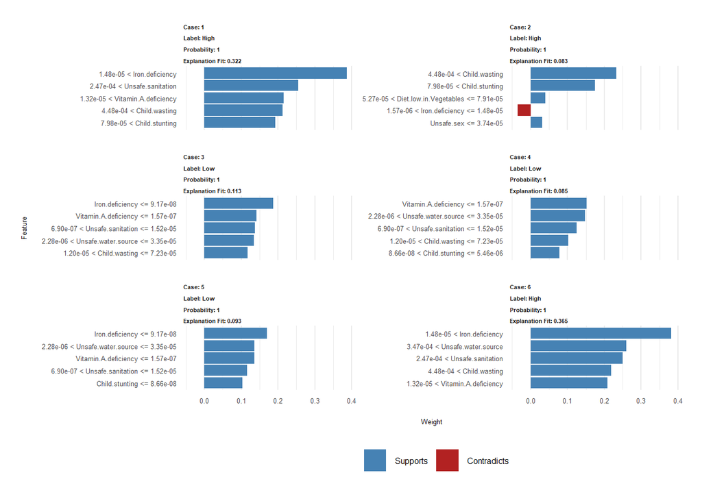

```r
#LIME
apply_lime(dTrain, dTest, model_bayes_2, "Low.birth.weight")
```

# 5. Models Comparation

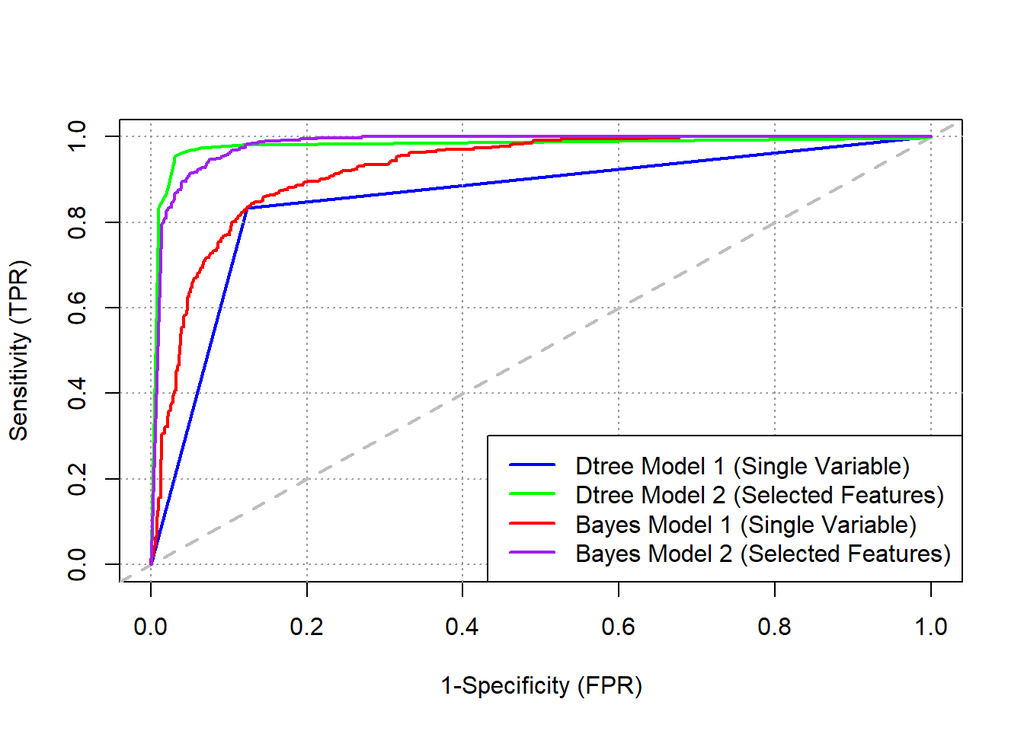

```r
library(ROCit)
# ROC plot
rocit_dtree_1 <- rocit(score = prob_dtree_1, class = dTest$Low.birth.weight, negref = "Low")
rocit_dtree_2 <- rocit(score = prob_dtree_2, class = dTest$Low.birth.weight, negref = "Low")
rocit_bayes_1 <- rocit(score = prob_bayes_1, class = dTest$Low.birth.weight, negref = "Low")
rocit_bayes_2 <- rocit(score = prob_bayes_2, class = dTest$Low.birth.weight, negref = "Low")

plot(rocit_dtree_1, col = c("blue", "gray"), main = "ROC Curves for Dtree and Bayes Models", lwd = 2, YIndex = F)

lines(rocit_dtree_2$TPR ~ rocit_dtree_2$FPR, col = "green", lwd = 2)
lines(rocit_bayes_1$TPR ~ rocit_bayes_1$FPR, col = "red", lwd = 2)
lines(rocit_bayes_2$TPR ~ rocit_bayes_2$FPR, col = "purple", lwd = 2)

# Add a legend
legend("bottomright",
       legend = c("Dtree Model 1 (Single Variable)",
                  "Dtree Model 2 (Selected Features)",
                  "Bayes Model 1 (Single Variable)",
                  "Bayes Model 2 (Selected Features)"),
       col = c("blue", "green", "red", "purple"),
       lwd = 2)
```

The ROC curve shows the performance of four models:

- Bayes Model 2 (Selected Features) (purple) performs excellent, with the highest sensitivity and specificity across most thresholds.
- Decision Tree Model 2 (Selected Features) (green) performance is closely with Bayes Model 2, showing excellent AUC.
- Bayes Model 1 (Single Variable) (red) also performs well, but slightly worse than Bayes Model 2.
- Decision Tree Model 1 (Single Variable) (blue) performs the worst, with a lower sensitivity compared to the other models.

```r
# AUC values for each model
# Combine the results into a data frame
comparison_df <- data.frame(
  Model = c("Dtree Model 1 (Single Variable)",
            "Dtree Model 2 (Selected Features)",
            "Bayes Model 1 (Single Variable)",
            "Bayes Model 2 (Selected Features)"),

  Accuracy = c(performance_dtree_1$Accuracy,
               performance_dtree_2$Accuracy,
               performance_bayes_1$Accuracy,
               performance_bayes_2$Accuracy),

  Precision = c(performance_dtree_1$Precision,
                performance_dtree_2$Precision,
                performance_bayes_1$Precision,
                performance_bayes_2$Precision),

  Recall = c(performance_dtree_1$Recall,
             performance_dtree_2$Recall,
             performance_bayes_1$Recall,
             performance_bayes_2$Recall),

  F1_Score = c(performance_dtree_1$F1_Score,
               performance_dtree_2$F1_Score,
               performance_bayes_1$F1_Score,
               performance_bayes_2$F1_Score),

  Kappa = c(performance_dtree_1$Kappa,
            performance_dtree_2$Kappa,
            performance_bayes_1$Kappa,
            performance_bayes_2$Kappa),

  AUC = c(performance_dtree_1$AUC,
          performance_dtree_2$AUC,
          performance_bayes_1$AUC,
          performance_bayes_2$AUC),

  McNemar_PValue = c(performance_dtree_1$McNemar_PValue,
                     performance_dtree_2$McNemar_PValue,
                     performance_bayes_1$McNemar_PValue,
                     performance_bayes_2$McNemar_PValue)
)

# Sort the dataframe by AUC in descending order
sorted_comparison_df <- comparison_df[order(-comparison_df$AUC), ]
# Convert the P-values to scientific notation
sorted_comparison_df$McNemar_PValue <- formatC(sorted_comparison_df$McNemar_PValue, format = "e", digits = 2)
# Print the sorted comparison table
kable(sorted_comparison_df, format = "html") %>%
  kable_styling(bootstrap_options = c("striped", "hover", "responsive")) %>%
  column_spec(c(1:8), extra_css = "white-space: nowrap;", border_right = TRUE) %>%
  scroll_box(height = "250px")
```

|  | Model | Accuracy | Precision | Recall | F1_Score | Kappa | AUC | McNemar_PValue |
| --- | --- | --- | --- | --- | --- | --- | --- | --- |
| 4 | Bayes Model 2 (Selected Features) | 0.9355109 | 0.9135802 | 0.8980583 | 0.9057528 | 0.8567449 | 0.9818675 | 4.94e-01 |
| 2 | Dtree Model 2 (Selected Features) | 0.9639866 | 0.9424460 | 0.9538835 | 0.9481303 | 0.9205500 | 0.9796467 | 5.42e-01 |
| 3 | Bayes Model 1 (Single Variable) | 0.8559464 | 0.7620087 | 0.8470874 | 0.8022989 | 0.6894894 | 0.9239224 | 6.01e-04 |
| 1 | Dtree Model 1 (Single Variable) | 0.8618090 | 0.7813212 | 0.8325243 | 0.8061105 | 0.6989263 | 0.8548811 | 4.30e-02 |

The table shows that Bayes Model 2 (Selected Features) and Decision Tree Model 2 (Selected Features) are the most excellent performance models, and their performance is very close. However, Bayes Model 2 (Selected Features) still has the highest AUC among other.

# V. Clustering

**The selection of methodology:**

- Hierarchical Clustering: This analysis is based on its effectiveness in handling numerical, continuous data, which K Means performs poorly. K Means also not suitable with data sets that have high number of outliers.
- Ward.D2: The data is numerical and continuous when variance minimization is essential. Although significant outliers might influence the Clustering since Ward’s method relies on minimizing variance, as normalization has already been conducted, this will minimize the impact.
- Euclidean Distance: Good for continuous, raw data and widely used for this type of case.

To conduct Clustering using Hierarchical Clustering, the data will be scaled.

```r
# Prepare the data:
data_clustering <- death_causes %>% select(-Allcauses,-GDP, -Entity, -Code, -Year, -Population)
data_clustering <- t(data_clustering)  # Transpose the data
scaled_df <- scale(data_clustering)  # Scale the data
```

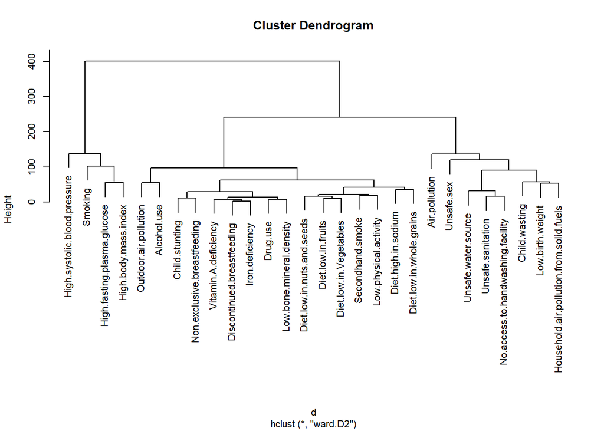

```r
# Perform hierarchical clustering on the rows (entities/countries)
# Compute the distance matrix
d <- dist(scaled_df, method = "euclidean")

# Perform hierarchical clustering using Ward's method
pfit <- hclust(d, method = "ward.D2")

# Plot the dendrogram without grouping the clusters
par(cex = 0.7)
plot(pfit, labels=names(data_clustering), main="Cluster Dendrogram")
```

**The methods to select best k value:**

- The Calinski-Harabasz (CH) Index: It will evaluate the quality of clustering and measures the ratio of between-cluster dispersion to within-cluster dispersion. A higher CH Index indicates well-separated clusters with compact members.
- Within-Cluster Sum of Squares (WSS) - Elbow Method: it can determine the optimal number of clusters by evaluating the decrease in WSS when the number of clusters increases.

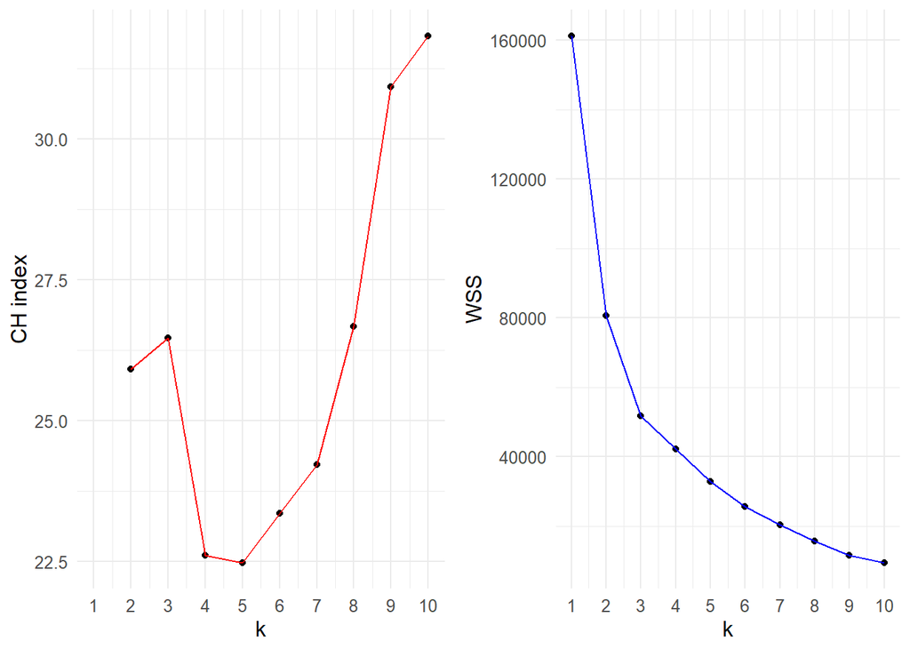

```r
# The squared Euclidean distance of two given points x and y
sqr_euDist <- function(x, y) {
  sum((x - y)^2)
}
# WSS of a cluster
wss <- function(clustermat) {
  c0 <- colMeans(clustermat)
  sum(apply(clustermat, 1, FUN = function(row) {sqr_euDist(row, c0)}))
}
# The total WSS.
wss_total <- function(scaled_df, labels) {
  wss.sum <- 0
  k <- length(unique(labels))
  for (i in 1:k) {
    wss.sum <- wss.sum + wss(subset(scaled_df, labels == i))
  }
  wss.sum
}
# The total sum of squares (TSS)
tss <- function(scaled_df) {
  wss(scaled_df)
}
# The CH index
CH_index <- function(scaled_df, kmax, method = "kmeans") {
  if (!(method %in% c("kmeans", "hclust")))
    stop("method must be one of c('kmeans', 'hclust')")

  npts <- nrow(scaled_df)
  wss.value <- numeric(kmax)  # Create a vector to store WSS values
  wss.value[1] <- wss(scaled_df)  # WSS for k=1 (one large cluster)

  if (method == "kmeans") {
    # kmeans clustering
    for (k in 2:kmax) {
      clustering <- kmeans(scaled_df, centers = k, nstart = 10, iter.max = 100)
      wss.value[k] <- clustering$tot.withinss
    }
  } else {
    # Hierarchical clustering
    d <- dist(scaled_df, method = "euclidean")
    pfit <- hclust(d, method = "ward.D2")
    for (k in 2:kmax) {
      labels <- cutree(pfit, k = k)
      wss.value[k] <- wss_total(scaled_df, labels)
    }
  }
  bss.value <- tss(scaled_df) - wss.value  # Between sum of squares (BSS)
  B <- bss.value / (0:(kmax - 1))  # Between-group variance (B)
  W <- wss.value / (npts - 1:kmax)  # Within-group variance (W)

  data.frame(k = 1:kmax, CH_index = B / W, WSS = wss.value)
}
# The CH criterion
crit.df <- CH_index(scaled_df, 10, method = "hclust")
# Plot the CH and WSS plot
fig1 <- ggplot(crit.df, aes(x = k, y = CH_index)) +
  geom_point(na.rm = TRUE) + geom_line(colour = "red",na.rm = TRUE) +
  scale_x_continuous(breaks = 1:10, labels = 1:10) + theme_minimal() +
  labs(y = "CH index") + theme(text = element_text(size = 12))
fig2 <- ggplot(crit.df, aes(x = k, y = WSS)) +
  geom_point(na.rm = TRUE) + geom_line(colour = "blue",na.rm = TRUE) +
  scale_x_continuous(breaks = 1:10, labels = 1:10) + theme_minimal() +
  theme(text = element_text(size = 12))
grid.arrange(fig1, fig2, nrow = 1)
```

```r
library(fpc)
kbest.p <- 5
invisible(capture.output({
  cboot.hclust <- clusterboot(scaled_df, clustermethod = hclustCBI, method = "ward.D2", k = kbest.p)
}))
summary(cboot.hclust$result)
```

```
##               Length Class  Mode
## result         7     hclust list
## noise          1     -none- logical
## nc             1     -none- numeric
## clusterlist    5     -none- list
## partition     28     -none- numeric
## clustermethod  1     -none- character
## nccl           1     -none- numeric
```

```r
# cboot.hclust$bootbrd = number of times a cluster is desolved.
(values <- 1 - cboot.hclust$bootbrd/100)
```

```
## [1] 0.98 0.69 0.78 0.87 0.44
```

Using k=5, there are 3 clusters that have stabilization probilities around and higher than 80%.

```r
kbest.p <- 3
invisible(capture.output({
  cboot.hclust <- clusterboot(scaled_df, clustermethod = hclustCBI, method = "ward.D2", k = kbest.p)
}))
summary(cboot.hclust$result)
```

```
##               Length Class  Mode
## result         7     hclust list
## noise          1     -none- logical
## nc             1     -none- numeric
## clusterlist    3     -none- list
## partition     28     -none- numeric
## clustermethod  1     -none- character
## nccl           1     -none- numeric
```

```r
# cboot.hclust$bootbrd = number of times a cluster is desolved.
(values <- 1 - cboot.hclust$bootbrd/100)
```

```
## [1] 1.00 0.92 0.92
```

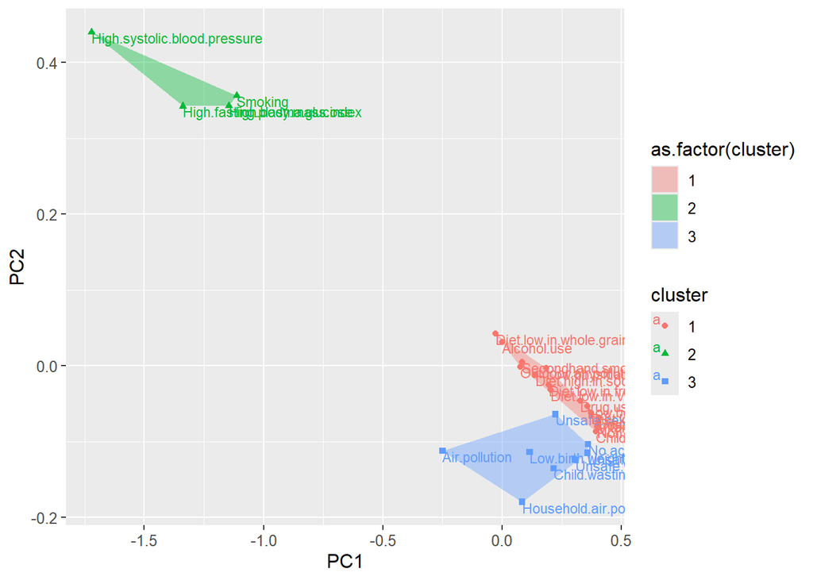

```r
library(grDevices)
# Best k
groups <- cutree(pfit, k = 3)
# Perform PCA on the scaled transposed data to calculate the principal components
princ <- prcomp(scaled_df)  # Perform PCA on the transposed and scaled data
nComp <- 2  # Focus on the first two principal components
# Project the scaled data onto the first 2 principal components to form a new 2-column data frame
project2D <- as.data.frame(predict(princ, newdata = scaled_df)[, 1:nComp])
Variable <- row.names(scaled_df)  # Use column names as identifiers
# Combine the projection, clusters, and variable names into one data frame
hclust.project2D <- cbind(project2D, cluster = as.factor(groups), Variable = Variable)
# Finding the convex hull for each cluster
find_convex_hull <- function(proj2Ddf, groups) { do.call(rbind,
  lapply(unique(groups),
   FUN = function(c) {
     f <- subset(proj2Ddf, cluster == c)  # Subset the data for each cluster
     f[chull(f$PC1, f$PC2), ] }))} # Apply convex hull on PC1 and PC2
# Calculate the convex hull for each cluster
hclust.hull <- find_convex_hull(hclust.project2D, groups)
# Plotting 2D clusters map
ggplot(hclust.project2D, aes(x = PC1, y = PC2)) +
  geom_point(aes(shape = cluster, color = cluster)) +
  geom_text(aes(label = Variable, color = cluster), hjust = 0, vjust = 1, size = 3) +
  geom_polygon(data = hclust.hull, aes(group = cluster, fill = as.factor(cluster)),
               alpha = 0.4, linetype = 0) +
  theme(text = element_text(size = 12))
```

The 2D clusters map show clear clusters showing that the clustering has high performance with k = 3.

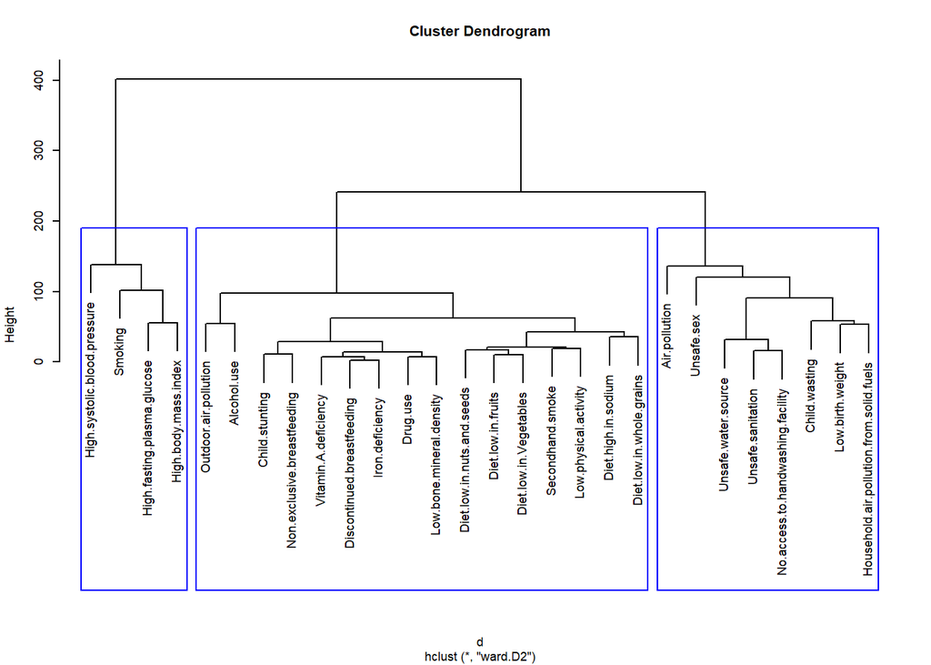

```r
par(cex = 0.55)
# Plot the dendrogram
plot(pfit, labels=names(data_clustering), main="Cluster Dendrogram")
rect.hclust(pfit, k=3, border = "blue",)
```

```r
# List of clustering with optimal k
groups <- sort(cutree(pfit, k = 3))

# Print group by group
for (i in unique(groups)) {
  cat("Group", i, ":\n")
  print(names(groups[groups == i]))  # Print the names of members in each group
  cat("\n")
}
```

```
## Group 1 :
##  [1] "Outdoor.air.pollution"       "Diet.high.in.sodium"
##  [3] "Diet.low.in.whole.grains"    "Alcohol.use"
##  [5] "Diet.low.in.fruits"          "Secondhand.smoke"
##  [7] "Diet.low.in.nuts.and.seeds"  "Diet.low.in.Vegetables"
##  [9] "Low.physical.activity"       "Drug.use"
## [11] "Low.bone.mineral.density"    "Vitamin.A.deficiency"
## [13] "Child.stunting"              "Discontinued.breastfeeding"
## [15] "Non.exclusive.breastfeeding" "Iron.deficiency"
##
## Group 2 :
## [1] "High.systolic.blood.pressure" "Smoking"
## [3] "High.fasting.plasma.glucose"  "High.body.mass.index"
##
## Group 3 :
## [1] "Unsafe.water.source"
## [2] "Low.birth.weight"
## [3] "Child.wasting"
## [4] "Unsafe.sex"
## [5] "Household.air.pollution.from.solid.fuels"
## [6] "Air.pollution"
## [7] "Unsafe.sanitation"
## [8] "No.access.to.handwashing.facility"
```

**Cluster interpretation:**

**Group 1:**

- In this group, there is a sub-group of causes that are related to the choice of diet, such as low intake of grains, fruits, vegetables, nuts, and high sodium intake.
- Another sub-group of causes is related to lifestyle habits such as alcohol and drug use, along with Low physical activity. Discontinued breastfeeding and Non-exclusive breastfeeding are also related to this group.
- In conclusion, this group could be the cause of death that is related to lifestyle selections and high-income countries, as already found in the correlation plot.

**Group 2:**

- This group contain Smoking, High systolic blood pressure, High fasting plasma glucose and High body mass index, which are highly related to each other. Therefore, this can be a group of cardiovascular problems.

**Group 3:**

- This group contains elements related to environmental health risks such as unsafe water sources, household air pollution, unsafe sanitation, and lack of access to handwashing facilities.
- Furthermore, child health-related causes such as low birth weight, child wasting, and unsafe sex are also clustered here.
- In conclusion, this group is highly related to low-income and developed countries.

# VI. Reference

- OpenAI, “GPT-4” accessed via web application interface for code suggestion and samples, Oct. 2024. [Online]. Available: https://chat.openai.com
- Benesty, TLP& M 2022, Understanding lime. Available from: https://cran.r-project.org/web/packages/lime/vignettes/Understanding_lime.html.
- Painuli, D, Bhardwaj, S, Kose, U, Gurukula Kangri Vishwavidyalaya, & Suleyman Demirel University 2023, “Optimized Speech Signal-based Diagnosis of Parkinson’s Disease using Machine Learning Techniques – Augmented by An Efficient Feature Selection & Hyperparameter Tuning Approach,” Unknown, p. 9523. Available from: https://mir-net.com/pdf/9523.pdf.
- Mladenova, T, Valova, I, Evstatiev, B, Valov, N, Varlyakov, I, Markov, T, Stoycheva, S, Mondeshka, L, & Markov, N 2024, “Evaluation of the efficiency of machine learning algorithms for identification of cattle behavior using accelerometer and gyroscope data,” AgriEngineering, vol. 6, no. 3, pp. 2179–2197. Available from: https://www.mdpi.com/2624-7402/6/3/128.